# Working with the mlr package

To become familiar with the mlr package and its widespread functionality, I created an Rmarkdown document with basic and advanced features from the mlr tutorial on mostly regression and classification problems with data available in R.

## Getting started

The first step is to create a **task**; this can be a classification, regression, survival, cluster, cost-sensitive classification or multilabel task. For example, let us start with the `iris` data set from which we wish to predict the `Species` based on features comprised of width and length measurements of sepals and petals.

```r
task <- makeClassifTask(data = iris, target = "Species")
```

There exist other options that can be set when calling the task function like, for instance, weights and blocking. The latter is for observations that are required to be considered together such that when resampling or cross-validating, grouped observations are included either all in the train or all in the test set.

Next, we choose a learner. Here, we choose to learn based on a classification tree fitted through the `rpart` function.

```r
lrn <- makeLearner("classif.rpart")
```

We can get a description of all possible parameter settings for a learner using `?getParamSet(lrn)`:

```r
getParamSet(lrn)
```

```
##                    Type len  Def   Constr Req Tunable Trafo
## minsplit        integer   -   20 1 to Inf   -    TRUE     -
## minbucket       integer   -    - 1 to Inf   -    TRUE     -
## cp              numeric   - 0.01   0 to 1   -    TRUE     -
## maxcompete      integer   -    4 0 to Inf   -    TRUE     -
## maxsurrogate    integer   -    5 0 to Inf   -    TRUE     -
## usesurrogate   discrete   -    2    0,1,2   -    TRUE     -
## surrogatestyle discrete   -    0      0,1   -    TRUE     -
## maxdepth        integer   -   30  1 to 30   -    TRUE     -
## xval            integer   -   10 0 to Inf   -   FALSE     -
## parms           untyped   -    -        -   -    TRUE     -
```

Further, we can create a description object for a resampling startegy using `makeResampleDesc`. For example, we may wish to carry out a 3-fold cross-validation of `rpart` on `iris`.

```r
cv3f <- makeResampleDesc("CV", iters = 3, stratify = TRUE )
```

Finally, we can fit the model specified by `lrn` on the `task` and calculate predictions and performance measures for all training and all test sets specified by the above resampling description.

```r
set.seed(123)
r <- resample(lrn, task, cv3f)
r$aggr
```

```
## mmce.test.mean
##     0.07295185
```

The mean misclassification error is given by 0.0729518. The default measure for a classification task is the misclassification error, `mmce` but it is possible to choose a different measure, say *accuracy*, `acc` which is given by 1 - `mmce`. We will see later that we can also define our own measures.

```r
set.seed(123)
r <- resample(lrn, task, cv3f, measures = acc)
r$aggr
```

```
## acc.test.mean
##     0.9270482
```

## Basics

### Tasks

As previously mentioned, depending on the type of problem at hand, one can define an appropriate task. We have seen an instance of a classification problem above, let us now look at a supervised regression problem using the `BostonHousing` data. By printing task, we get some information on the task object we have just created and the associated data.

```r
data(BostonHousing, package = "mlbench")
task <- makeRegrTask(data = BostonHousing, target = "medv")
print(task)
```

```
## Supervised task: BostonHousing
## Type: regr
## Target: medv
## Observations: 506
## Features:
## numerics  factors  ordered
##       12        1        0
## Missings: FALSE
## Has weights: FALSE
## Has blocking: FALSE
```

#### Modifying a task

Once the task is created, it can be modified in several ways. For example, the function `subsetTask` allows the selection of certain observations and/or features.

```r
names(BostonHousing)
```

```
##  [1] "crim"    "zn"      "indus"   "chas"    "nox"     "rm"      "age"
##  [8] "dis"     "rad"     "tax"     "ptratio" "b"       "lstat"   "medv"
```

```r
modifiedtask <- subsetTask(task, subset = 1:400, features = c("crim", "age", "dis", "lstat"))
str(getTaskData(modifiedtask))
```

```
## 'data.frame':    400 obs. of  5 variables:
##  $ crim : num  0.00632 0.02731 0.02729 0.03237 0.06905 ...
##  $ age  : num  65.2 78.9 61.1 45.8 54.2 58.7 66.6 96.1 100 85.9 ...
##  $ dis  : num  4.09 4.97 4.97 6.06 6.06 ...
##  $ lstat: num  4.98 9.14 4.03 2.94 5.33 ...
##  $ medv : num  24 21.6 34.7 33.4 36.2 28.7 22.9 27.1 16.5 18.9 ...
```

Using `getTaskData` we can see that the modified task now includes 400 observations and 5 variables (the 4 included in the features character vector above and the target variable which will always be included). Some other useful functions are the following:

1. `removeConstantFeatures(<task name>)`:

constant features may arise dur to an inherent feature in the data collected or as a result of choosing a subset of observations.

2. `dropFeatures(task, c("rm", "nox"))`:

remove selected features from the task.

3. `normalizeFeatures(task, method = "standardize")`:

normalize numerical features by different methods (nonnumerical features are left untouched). The normalizing method can be one of `center` (subtract mean), `scale` (divide by standard deviation), `standardize` (center and scale), `range` (scale to a given range - default is [0, 1]). The optional argument `exclude` may be used to supply a character vector of columns to be excluded from the normalization. Type `?normalizeFeatures` for more info.

### Learners

Many of the popular learning algorithms are already implemented in `mlr`. The `makeLearner` function requires the user to specify the learning method. Additionally, it is possible to modify defaults on the prediction type (i.e. for classification, we may choose `predict.type = "prob"` for probabilities), or set hyperparameters using a `list` passed to the `par.vals` argument.

```r
class.lrn <- makeLearner("classif.randomForest", predict.type = "prob", fix.factors.prediction = TRUE)
regr.lrn <- makeLearner("regr.gbm", par.vals = list(n.trees = 500, interaction.depth = 4))
#cluster.lrn <- makeLearner("cluster.SimpleKMeans", N = 5)
```

Note that the `fix.factors.prediction = TRUE` argument is useful in situations where a factor level is present in the training data set but not the test data set; it adds a factor level for missing data in the test set thus avoiding problems.

The Learner object is a list and information can be extracted using the `$`, e.g. `regr.lrn$par.vals`. This information can also be accessed using other functions in `mlr`, for instance, `getHyperPars(lrn)` retrieves the current hyperparameter settings of the learner `lrn`. We also used above `getParamSet(lrn)` to get a description of all possible parameter settings for `lrn`.

#### Modifying a learner

Just like it was possible to modify an existing task, we can also do so for a learner. Modifications include changing the `id` (this is either user specified or, if omitted, it is automatically set to the algorithm name), the prediction type, hyperparameter values, and more.

```r
class.lrn <- setPredictType(class.lrn, "response")
regr.lrn <- setHyperPars(regr.lrn, n.trees = 400)
regr.lrn <- removeHyperPars(regr.lrn, c("n.trees", "interaction.depth"))
```

Note `removeHyperPars` sets the hyperparameters back to their default values.

### Train

Once we create the task from the data set and identify the learning algorithm, the next step is to train the learner using the `train` command.

```r
task <- makeClassifTask(data = iris, target = "Species")
lrn <- makeLearner("classif.lda")
mod <- mlr::train(lrn, task)
mod
```

```
## Model for learner.id=classif.lda; learner.class=classif.lda
## Trained on: task.id = iris; obs = 150; features = 4
## Hyperparameters:
```

The function `train` returns a list. The fitted model can be extracted using the `getLearnerModel(mod)` command. It is possible to choose a subset of observations to be used to train the model; this is achieved via the `subset` argument in `train`. Note that this is usually not needed since resampling strategies are supported. In the following example, we use the `BostonHousing` data to fit a linear model to the regression task. Note that `getTaskSize` returns the number of observations in a task.

```r
data(BostonHousing, package = "mlbench")
task <- makeRegrTask(data = BostonHousing, target = "medv")
lrn <- makeLearner("regr.lm")
train.set <- sample(getTaskSize(task), size = getTaskSize(task)/3)
mod <- mlr::train(lrn, task, subset = train.set)
getLearnerModel(mod)
```

```
##
## Call:
## stats::lm(formula = f, data = d)
##
## Coefficients:
## (Intercept)         crim           zn        indus        chas1
##   38.578002    -0.118996     0.060324     0.102993     1.118329
##         nox           rm          age          dis          rad
##  -26.669634     3.957466    -0.003478    -1.616870     0.378537
##         tax      ptratio            b        lstat
##   -0.015915    -0.793560     0.007297    -0.512330
```

Finally, a note on weights passed as an argument in the `train` function. As an example for an application of weights [^1] used in `train`, consider the `BreastCancer` data for which the target variable `Class` identifies 241 malignant and 458 benign cases. To deal with the imbalanced classes, we can incorporate weights in an attempt to allow the two classes to be equally represented in training the classifier. Here we use the predefined task `bc.task` in mlr. The `getTaskTargets` function gets the target data from a task (in this example, this is equivalent to the vector `BreastCancer$Class`). Note that if weights are defined in task as well then those would be overwritten by the weights in `train`.

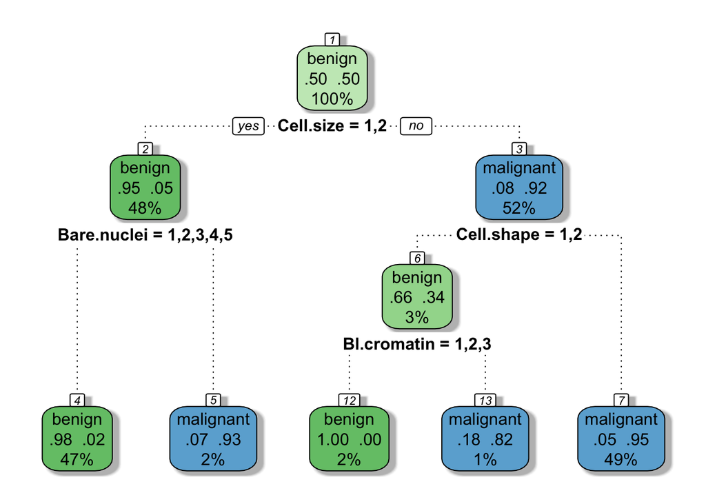

```r
target <- getTaskTargets(bc.task)
tab <- as.numeric(table(target))
#obtain inverse class frequencies for the weights
w <- 1/tab[target]
mod <-mlr:: train("classif.rpart", task = bc.task, weights = w)
fancyRpartPlot(getLearnerModel(mod), sub = "")
```

Weights can also be useful as a means to grant more importance to recently collected data versus older data or to reduce the influence of outliers.

### Predict

To predict target values, we use the `predict` function which takes as input the object returned by `train` and data for which we want predictions. The data can either come from the task (using the `task` argument) or it can be a data frame (passed using the `newdata` argument). Similarly to the `train` function, the `subset` argument may be used to pass different portions of the data in task.

```r
n <- getTaskSize(bh.task)
train.set <- seq(1, n, by = 2)
test.set <- seq(2, n, by = 2)
lrn <- makeLearner("regr.gbm", n.trees = 100, interaction.depth = 4)
mod <- mlr::train(lrn, bh.task, subset = train.set)
preds <- predict(mod, task = bh.task, subset = test.set)
preds
```

```
## Prediction: 253 observations
## predict.type: response
## threshold:
## time: 0.00
##    id truth response
## 2   2  21.6 22.45613
## 4   4  33.4 23.47600
## 6   6  28.7 22.67572
## 8   8  27.1 21.83028
## 10 10  18.9 21.86525
## 12 12  18.9 22.33298
```

The function `predict` returns a list; The `$data` element of that list contains the true values of the target variable (in case of supervised learning) and the predictions. A direct way to obtain the true and predicted values of the target variable is through the `getPredictionTruth(preds)` and `getPredictionResponse(preds)` commands where `preds` is the list returned by the `predict` function.

```r
head(getPredictionTruth(preds), 10)
```

```
##  [1] 21.6 33.4 28.7 27.1 18.9 18.9 20.4 19.9 17.5 18.2
```

```r
head(getPredictionResponse(preds), 10)
```

```
##  [1] 22.45613 23.47600 22.67572 21.83028 21.86525 22.33298 22.52053
##  [8] 22.51713 22.24673 22.33986
```

For classification problems, class labels are predicted. We can obtain a confusion matrix through the command `getConfMatrix`. To get predicted posterior probabilities, we need to create the learner with `predict.type = "prob"`.

```r
lrn <- makeLearner("classif.rpart", predict.type = "prob")
mod <- mlr::train(lrn, iris.task)
preds <- predict(mod, newdata = iris)
head(as.data.frame(preds))
```

```
##    truth prob.setosa prob.versicolor prob.virginica response
## 1 setosa           1               0              0   setosa
## 2 setosa           1               0              0   setosa
## 3 setosa           1               0              0   setosa
## 4 setosa           1               0              0   setosa
## 5 setosa           1               0              0   setosa
## 6 setosa           1               0              0   setosa
```

```r
head(getPredictionProbabilities(preds))
```

```
##   setosa versicolor virginica
## 1      1          0         0
## 2      1          0         0
## 3      1          0         0
## 4      1          0         0
## 5      1          0         0
## 6      1          0         0
```

We can also adjust the threshold value that is used to map the predicted posterior probabilities to the class labels. The default value for binary classification is 0.5; however, it may be necessary to increase/decrease this value in various situations such as in the case of classifying cancer rates where one would be concerned with false negatives (prediction of no cancer when the truth is yes cancer). By changing the threshold we change the sensitivity of the model. An example for adjusting the threshold in a binary classification setting is shown below.

```r
data(Sonar)
table(Sonar$Class)
```

```
##
##   M   R
## 111  97
```

```r
getTaskDescription(sonar.task)$positive
```

```
## [1] "M"
```

```r
lrn <- makeLearner("classif.rpart", predict.type = "prob")
mod <- mlr::train(lrn, task = sonar.task)
# predict with default threshold
preds <- predict(mod, sonar.task)
preds$threshold
```

```
##   M   R
## 0.5 0.5
```

```r
# set threshold value for +ve class
preds2 <- setThreshold(preds, 0.9)
# confusion matrices
getConfMatrix(preds)
```

```
##        predicted
## true     M  R -SUM-
##   M     95 16    16
##   R     10 87    10
##   -SUM- 10 16    26
```

```r
getConfMatrix(preds2)
```

```
##        predicted
## true     M  R -SUM-
##   M     84 27    27
##   R      6 91     6
##   -SUM-  6 27    33
```

For multiclass classification problems, the threshold is given by a named vector specifying the values by which each probability will be divided.

### Performance

There are many available performance measures implemented in mlr but one can also create their own performance measures. For a particular prediction object, say `preds` calling `performance(preds)` will give the calculated performance measure. It is also possible to calculate the time needed to train the learner (passing `timetrain` as an argument - see below), the time needed to compute the prediction (`timepredict`) or both (`timeboth`).

To obtain a list of available measures suitable for a particular problem type or `task`, use the `listMeasures` argument. The function `getDefaultMeasure` shows the defaults for a particular learner or task.

```r
listMeasures("classif", properties = "classif.multi")
```

```
## [1] "timepredict"    "acc"            "ber"            "featperc"
## [5] "mmce"           "timeboth"       "timetrain"      "multiclass.auc"
```

```r
getDefaultMeasure(bh.task)
```

```
## Name: Mean of squared errors
## Performance measure: mse
## Properties: regr,req.pred,req.truth
## Minimize: TRUE
## Best: 0; Worst: Inf
## Aggregated by: test.mean
## Note:
```

The following piece of `R` code shows how to obtain the performance measure from the prediction object.

```r
n <- getTaskSize(bh.task)
train.set <- seq(1, n, by = 2)
test.set <- seq(1, n, by = 2)
lrn <- makeLearner("regr.gbm", n.trees = 1000)
mod <- mlr::train(lrn, task = bh.task, subset = train.set)
preds <- predict(mod, task = bh.task, subset = test.set)
performance(preds)
```

```
##      mse
## 38.45852
```

To change the performance measure, we can do so via the `measures` argument. It is possible to calculate several performance measures by passing them as a list.

```r
performance(preds, measures = medse)
```

```
##    medse
## 10.29158
```

```r
performance(preds, measures = list(mse, medse, mae))
```

```
##       mse     medse       mae
## 38.458520 10.291584  4.412879
```

It is a necessary requirement to pass the model or the task in order to calculate some performance measures. For instance, for `timetrain` calculations, the model also needs to be passed as ar argument.

```r
performance(preds, measures = timetrain, model = mod)
```

```
## timetrain
##      0.06
```

For clustering problems, the task is required.

```r
lrn <- makeLearner("cluster.kmeans", centers = 3)
mod <- mlr::train(lrn, task = mtcars.task)
preds <- predict(mod, task = mtcars.task)
performance(preds, measures = dunn, task = mtcars.task)
```

```
##      dunn
## 0.1178415
```

```r
lrn <- makeLearner("classif.lda", predict.type = "prob")
n <- getTaskSize(sonar.task)
train.set <- seq(1, n, by = 2)
test.set <- seq (2, n, by = 2)
mod <- mlr::train(lrn, task = sonar.task, subset = train.set)
preds <- predict(mod, task = sonar.task, subset = test.set)
performance(preds, measures = list(fpr, fnr, mmce))
```

```
##       fpr       fnr      mmce
## 0.2500000 0.3035714 0.2788462
```

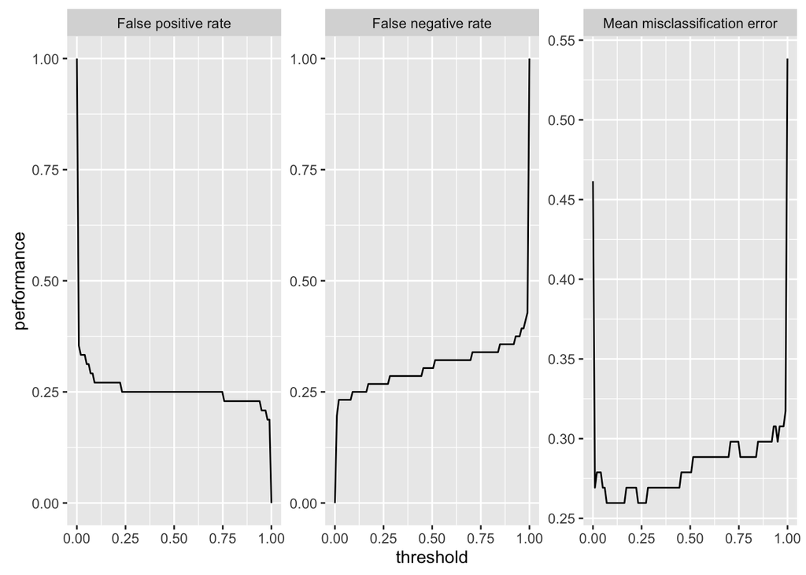

```r
d <- generateThreshVsPerfData(preds, measures = list(fpr, fnr, mmce))
plotThreshVsPerf(d)
```

### Resampling

Resampling strategies are often used to assess the performance of a learning algorithm by splitting the data into multiple training and test sets. Each training set is used to train a learner and each test set is reserved for predictions. We get the mean performance measure obtained by agreggating all individual performances. The `makeResampleDesc` function is used to choose the resampling strategy; the method argument can be set to one of cross-validation, leave-one-out cross-validation, repeated cross-validation, out-of-bag bootstrap, subsampling (a.k.a. *Monte-Carlo* cross-validation), and holdout. Additional arguments can be passed to the function depending on the chosen method. Once the resampling description is specified, we use the function `resample` to fit a model specified by a learner on a task, which calculates predictions and performance measures for all training and test sets as specified by the resampling description.

```r
rdesc <- makeResampleDesc("CV", iters = 3, stratify = TRUE)
task <- makeClassifTask(data = iris, target = "Species")
lrn <- makeLearner("classif.rpart")
r <- resample(lrn, task, rdesc)
```

```
## [Resample] cross-validation iter: 1
```

```
## [Resample] cross-validation iter: 2
```

```
## [Resample] cross-validation iter: 3
```

```
## [Resample] Result: mmce.test.mean=0.0732
```

```r
r
```

```
## Resample Result
## Task: iris
## Learner: classif.rpart
## mmce.aggr: 0.07
## mmce.mean: 0.07
## mmce.sd: 0.01
## Runtime: 0.0346839
```

```r
r$measures.test
```

```
##   iter       mmce
## 1    1 0.07843137
## 2    2 0.06122449
## 3    3 0.08000000
```

```r
r$aggr
```

```
## mmce.test.mean
##     0.07321862
```

```r
r$measures.train
```

```
##   iter mmce
## 1    1   NA
## 2    2   NA
## 3    3   NA
```

The `resample` function returns a list whose elements we can access using the `$` notation. In the above exmaple `r$measures.test` gives the performance on the 3 individual test sets (as specified in the resampling description) and `r$measures.train` returns missing values since no predictions on the training sets were made. If we wish to have predictions on the training sets we can set `predict = "both"` or `predict = "train"` as an argument in `makeResampleDesc`.

Next, we can access `r$pred$data` which gives a data frame of the predictions and true (in supervised learning) values of the target variable. Note that it is possible to pass multiple measures as a list in `resample` (including `timetrain`).

```r
head(r$pred$data)
```

```
##   id  truth response iter  set
## 1  4 setosa   setosa    1 test
## 2  5 setosa   setosa    1 test
## 3  6 setosa   setosa    1 test
## 4  8 setosa   setosa    1 test
## 5 16 setosa   setosa    1 test
## 6 20 setosa   setosa    1 test
```

*Stratified resampling* ensures that the same proportion of the classes falls in all partitions of the data such that, in a classification setting, each training/test set trains a model with no class being under-represented. This is especially important in small data sets as well as imbalanced classification problems. The `stratify = TRUE` argument is passed when making the resampling description (as in the `R` code above). The `stratify.cols = <col. name>` argument is used to stratify factor variable inputs to ensure that all subgroups are represented in the data partitions.

#### Accessing individual learners

By default, `resample` does not return the individual learners but can do so by passing the argument `models = TRUE` when calling `resample`. More useful still, is to extract certain information from each model like, for instance, the variable importance for chosen models. This is achieved via the `extract` argument.

```r
rdesc <- makeResampleDesc("CV", iters = 3)
lrn <- makeLearner("regr.rpart")
r <- resample(lrn, task = bh.task, resampling = rdesc, extract = function(x)
  x$learner.model$variable.importance, models = FALSE)
```

```
## [Resample] cross-validation iter: 1
```

```
## [Resample] cross-validation iter: 2
```

```
## [Resample] cross-validation iter: 3
```

```
## [Resample] Result: mse.test.mean=25.4
```

```r
r$extract
```

```
## [[1]]
##         rm      lstat      indus    ptratio        nox        age
## 18617.3719 14071.2906  4926.4376  3997.0454  3367.8188  2993.7238
##       crim        tax        dis         zn          b        rad
##  2937.2363  2827.4408  2576.0851  2132.4695   711.8396   298.7435
##
## [[2]]
##         rm      lstat       crim        age      indus    ptratio
## 17499.4752 12103.1335  3718.0924  3143.2565  3060.3740  3006.6774
##        dis        nox         zn        rad        tax          b
##  2945.8373  2892.6036  1575.9143   726.0415   686.3487   510.1821
##       chas
##   474.2825
##
## [[3]]
##     lstat     indus       nox      crim        rm       age       dis
## 13384.166  8649.907  8450.450  7779.603  7727.961  7517.997  4408.284
##   ptratio       tax        zn
##  2077.555  1430.559   172.779
```

Now, `r$extract` is going to give information on the given function from which we asked to obtain the variable importance. With `models = FALSE` we do not obtain other information on the model so attempting to call `getLearnerModel(r$models[[1]])` would return an error.

#### Resample instance

The command `makeResampleInstance` takes as arguments an object of class ResampleDesc and a task [or the size of the data set i.e. nrow()]. This creates a ResampleInstance object which mainly stores the indices of the training and test sets used in each iteration. This feature may be useful in situations where we want to perform paired experiments like testing the performance of several learners on exactly the same data.

```r
rdesc <- makeResampleDesc("CV", iters = 3, stratify = TRUE)
rin <- makeResampleInstance(rdesc, task = iris.task)
rin$train.inds[[2]]
```

```
##   [1]  21  24   2  13  27  17  35   6  19  12  30  32  45  26  18   5  22
##  [18]  43  15  33  49  47  41  29  44  14  23   1   3  38   4  34  28  86
##  [35]  99  93  89  56  53  84  51  69  67  91  80  77  62  58  95  85  97
##  [52]  74  65  68  83  98  63  70  92  57  61  66  79  52  90  88 104 108
##  [69] 107 148 113 149 124 105 126 141 127 129 119 109 150 144 125 101 118
##  [86] 114 138 112 142 140 115 110 103 106 139 134 111 137 102 135
```

In `makeResampleInstance` the indices are drawn randomly; the function `makeFixedHoldoutInstance` allows the training and test sets to be specified manually.

```r
rin <- makeFixedHoldoutInstance(train.inds = 1:100, test.inds = 101:150, size = 150)
rin
```

```
## Resample instance for 150 cases.
## Resample description: holdout with 0.67 split rate.
## Predict: test
## Stratification: FALSE
```

In resampling startegies, we get a performance measure which is aggregated over all the measures calculated for each iteration. By default, the aggregated score is the mean error on the test set. We can change the aggregation method for a measure via `setAggregation(measure, aggr)`. For the different options for `measure` and `aggr` type `?measures` and `?aggregations`, respectively.

```r
m1 <- mmce
m2 <- setAggregation(tpr, test.median) # tpr = true positive rate
rdesc <- makeResampleDesc("CV", iters = 3)
r <- resample("classif.rpart", task = sonar.task, resampling = rdesc, measures = list(m1,m2))
```

```
## [Resample] cross-validation iter: 1
```

```
## [Resample] cross-validation iter: 2
```

```
## [Resample] cross-validation iter: 3
```

```
## [Resample] Result: mmce.test.mean=0.274,tpr.test.median= 0.8
```

```r
r$aggr
```

```
##  mmce.test.mean tpr.test.median
##       0.2740511       0.8000000
```

To get predictions on both training and test sets, we need to set `predict = "both"` in `makeResampleDesc` and set the aggregation method to `train.mean` if we wish to calculate the mean. An example is shown below.

```r
train.mmce <- setAggregation(mmce, train.mean)
rdesc <- makeResampleDesc("CV", iters = 3, predict = "both")
r <- resample("classif.rpart", task = sonar.task, resampling = rdesc, measures = list(mmce, train.mmce))
```

```
## [Resample] cross-validation iter: 1
```

```
## [Resample] cross-validation iter: 2
```

```
## [Resample] cross-validation iter: 3
```

```
## [Resample] Result: mmce.test.mean=0.289,mmce.train.mean=0.113
```

```r
r$aggr
```

```
##  mmce.test.mean mmce.train.mean
##       0.2888199       0.1129357
```

There exist functions which act as convenience wrappers for the various existing resampling strategies. They don’t offer as much flexibility as `resample` but can be quick and useful if trying out a number of learners initially. An example with `crossval` is shown below.

```r
cviris <- crossval("classif.lda", task = iris.task, iters = 3, measures = list(mmce, ber))
```

```
## [Resample] cross-validation iter: 1
```

```
## [Resample] cross-validation iter: 2
```

```
## [Resample] cross-validation iter: 3
```

```
## [Resample] Result: mmce.test.mean=0.02,ber.test.mean=0.0223
```

```r
cviris
```

```
## Resample Result
## Task: iris-example
## Learner: classif.lda
## mmce.aggr: 0.02
## mmce.mean: 0.02
## mmce.sd: 0.02
## ber.aggr: 0.02
## ber.mean: 0.02
## ber.sd: 0.02
## Runtime: 0.031888
```

### Benchmark experiments

Using `benchmark`, we can compare different learning algorithms across one or more tasks w.r.t. a given resampling strategy. The function has the advantage of conducting *paired* experiments thus comparing the same training/test sets for the different learners. In the following `R` code, we specify a single task (here, we use the built in `sonar.task`) and apply a LDA and a classification tree learner. The resampling strategy is chosen as `Holdout` hence the performance is calculated on a single randomly sampled test set.

```r
lrns <- list(makeLearner("classif.lda"), makeLearner("classif.rpart"))
rdesc <- makeResampleDesc("Holdout")
bmr <- benchmark(learners = lrns, tasks = sonar.task, resamplings = rdesc)
```

```
## Task: Sonar-example, Learner: classif.lda
```

```
## [Resample] holdout iter: 1
```

```
## [Resample] Result: mmce.test.mean= 0.3
```

```
## Task: Sonar-example, Learner: classif.rpart
```

```
## [Resample] holdout iter: 1
```

```
## [Resample] Result: mmce.test.mean=0.314
```

```r
bmr
```

```
##         task.id    learner.id mmce.test.mean
## 1 Sonar-example   classif.lda      0.3000000
## 2 Sonar-example classif.rpart      0.3142857
```

The function `benchmark` returns an object of class BenchmarkResult which contains a list of lists of ResampleResult objects ordered by task and followed by learner. The mlr `getBMR<...>` commands allows access to the benchmark results.

#### Learner performances

```r
getBMRPerformances(bmr, as.df = TRUE)
```

```
##         task.id    learner.id iter      mmce
## 1 Sonar-example   classif.lda    1 0.3000000
## 2 Sonar-example classif.rpart    1 0.3142857
```

```r
getBMRAggrPerformances(bmr, as.df = TRUE)
```

```
##         task.id    learner.id mmce.test.mean
## 1 Sonar-example   classif.lda      0.3000000
## 2 Sonar-example classif.rpart      0.3142857
```

The two results (top: individual performance in resampling runs, bottom: aggregated performance values) coincide since `Holdout` was used as the resampling strategy. The optional argument `as.df = TRUE` returns the results in the form of a data frame which is often more convenient.

#### Predictions

By default, `keep.pred = TRUE` in `benchmark` which allows the user to access the predictions with `getBMRPredictions`. If `keep.pred = FALSE`, the following command will result in an error.

```r
head(getBMRPredictions(bmr, as.df = TRUE))
```

```
##         task.id  learner.id  id truth response iter  set
## 1 Sonar-example classif.lda  77     R        R    1 test
## 2 Sonar-example classif.lda 107     M        M    1 test
## 3 Sonar-example classif.lda  87     R        R    1 test
## 4 Sonar-example classif.lda  85     R        M    1 test
## 5 Sonar-example classif.lda  52     R        R    1 test
## 6 Sonar-example classif.lda 128     M        R    1 test
```

The learner and task ID is automatically set to the name of the algorithm and task if not explicitly specified. Using the ID in `getBMRPredictions`, it is possible to access results for certain learners or tasks. For instance below, we obtain the predictions from the classification tree learner.

```r
head(getBMRPredictions(bmr, learner.ids = "classif.rpart", as.df = TRUE))
```

```
##           task.id    learner.id  id truth response iter  set
## 77  Sonar-example classif.rpart  77     R        R    1 test
## 107 Sonar-example classif.rpart 107     M        R    1 test
## 87  Sonar-example classif.rpart  87     R        M    1 test
## 85  Sonar-example classif.rpart  85     R        R    1 test
## 52  Sonar-example classif.rpart  52     R        R    1 test
## 128 Sonar-example classif.rpart 128     M        M    1 test
```

If unsure of the ID for the learner, task, and performance measure, they can be accessed using `getBMRLearnerIds`, `getBMRTaskIds`, and `getBMRMeasureIds`, respectively.

#### Models

Similarly, to *Predictions* above, the argument `models = FALSE` must be set in `benchmark` if the user does not want to keep the fitted models for all learners and tasks. If set to true (default), the models may be accessed through `getBMRModels`.

```r
getBMRModels(bmr, learner.ids = "classif.lda")
```

```
## $`Sonar-example`
## $`Sonar-example`$classif.lda
## $`Sonar-example`$classif.lda[[1]]
## Model for learner.id=classif.lda; learner.class=classif.lda
## Trained on: task.id = Sonar-example; obs = 138; features = 60
## Hyperparameters:
```

More `getBMR<...>` functions exist to extract information on learners, measures, and more.

#### Additional benchmark experiments and merging results

Once a benchmark experiment has been conducted on a task, we may need to add more learners (or, alternatively, we may wish to extend existing learners to other tasks). We can perform another benchmark experiment and then merge the results (through either `mergeBenchmarkResultLearner` or `mergeBenchmarkResultTask`). As an example, we perform another benchmark experiment on `sonar.task` now with random forest and quadratic discriminant analysis learning algorithms. We then fuse this with the `bmr` object we obtained above to get a single `BenchmarkResult` object.

```r
lrns2 <- list(makeLearner("classif.randomForest"), makeLearner("classif.qda"))
bmr2 <- benchmark(learners = lrns2, tasks = sonar.task, resamplings = rdesc, show.info = FALSE)
bmr2
```

```
##         task.id           learner.id mmce.test.mean
## 1 Sonar-example classif.randomForest      0.1571429
## 2 Sonar-example          classif.qda      0.3857143
```

```r
bmrsingle <- mergeBenchmarkResultLearner(bmr, bmr2)
bmrsingle
```

```
##         task.id           learner.id mmce.test.mean
## 1 Sonar-example          classif.lda      0.3000000
## 2 Sonar-example        classif.rpart      0.3142857
## 3 Sonar-example classif.randomForest      0.1571429
## 4 Sonar-example          classif.qda      0.3857143
```

However, note that the resampling description was passed to `benchmark` twice, once to obtain the `bmr` and then the `bmr2` objects. The training/test pairs therefore were most likely different in the first benchmark call than the second. For more accurate merging of benchmark results, we can opt to work with `ResampleInstance` from the start, or extract the `ResampleInstance` from the resample description in the first benchmark call and pass it as argument in later benchmark calls. An example is given below.

```r
rin <- getBMRPredictions(bmr)[[1]][[1]]$instance
rin
```

```
## Resample instance for 208 cases.
## Resample description: holdout with 0.67 split rate.
## Predict: test
## Stratification: FALSE
```

```r
bmr3 <- benchmark(learners = lrns2, tasks = sonar.task, resamplings = rin, show.info = FALSE)
mergeBenchmarkResultLearner(bmr, bmr3)
```

```
##         task.id           learner.id mmce.test.mean
## 1 Sonar-example          classif.lda      0.3000000
## 2 Sonar-example        classif.rpart      0.3142857
## 3 Sonar-example classif.randomForest      0.1571429
## 4 Sonar-example          classif.qda      0.4000000
```

#### Benchmark analysis & visualization

Once benchmark experiments are conducted for the various learners and tasks, we may wish to rank and assess the performance of various algorithms, perform hypotheses tests or visualize the results. The mlr package offers various functions to do so and we explore some of these below using a longer benchmark example than the one above.

```r
# list of 3 learners
lrns <-list(makeLearner("classif.lda", id = "lda"), makeLearner("classif.rpart", id = "rpart"), makeLearner("classif.randomForest", id = "randomForest"))
# convertMLBenchObjToTask does exactly what it says... here we create 2 tasks
ring.task <- convertMLBenchObjToTask("mlbench.ringnorm", n = 600)
wave.task <- convertMLBenchObjToTask("mlbench.waveform", n = 600)
tasks <- list(iris.task, sonar.task, pid.task, ring.task, wave.task)
# 10-fold cross-validation
rdesc <- makeResampleDesc("CV", iters = 10)
meas <- list(mmce, ber, timetrain)
bmr <- benchmark(learners = lrns, tasks = tasks, resamplings = rdesc, measures = meas, show.info = FALSE)
bmr
```

```
##                        task.id   learner.id mmce.test.mean ber.test.mean
## 1                 iris-example          lda     0.02000000    0.02083333
## 2                 iris-example        rpart     0.05333333    0.05309524
## 3                 iris-example randomForest     0.03333333    0.02809524
## 4             mlbench.ringnorm          lda     0.36833333    0.37033082
## 5             mlbench.ringnorm        rpart     0.21500000    0.21793388
## 6             mlbench.ringnorm randomForest     0.06333333    0.06245273
## 7             mlbench.waveform          lda     0.17333333    0.17501347
## 8             mlbench.waveform        rpart     0.27333333    0.27457459
## 9             mlbench.waveform randomForest     0.15500000    0.15711244
## 10 PimaIndiansDiabetes-example          lda     0.23051948    0.27912739
## 11 PimaIndiansDiabetes-example        rpart     0.25264867    0.28804489
## 12 PimaIndiansDiabetes-example randomForest     0.23573137    0.27437875
## 13               Sonar-example          lda     0.25404762    0.25764222
## 14               Sonar-example        rpart     0.27857143    0.27835054
```

[output cut: 17 more lines]

The individual performances on each iteration for each learner, task, and measure can be accessed via `getBMRPerformances` as shown below:

```r
perf <- getBMRPerformances(bmr, as.df = TRUE)
head(perf)
```

```
##        task.id learner.id iter       mmce        ber timetrain
## 1 iris-example        lda    1 0.00000000 0.00000000     0.003
## 2 iris-example        lda    2 0.00000000 0.00000000     0.002
## 3 iris-example        lda    3 0.00000000 0.00000000     0.003
## 4 iris-example        lda    4 0.00000000 0.00000000     0.002
## 5 iris-example        lda    5 0.13333333 0.12500000     0.003
## 6 iris-example        lda    6 0.06666667 0.08333333     0.003
```

Performance tables like the one shown above get increasingly harder to read and comprehend with more experiments. A more convenient way to view the results is by plotting and visualization.

#### Plots

The function `plotBMRBoxplots` takes as input a benchmark object and displays a selected performance measure for all tasks and for all learners as a box or violin plot using the `ggplot2` graphics.

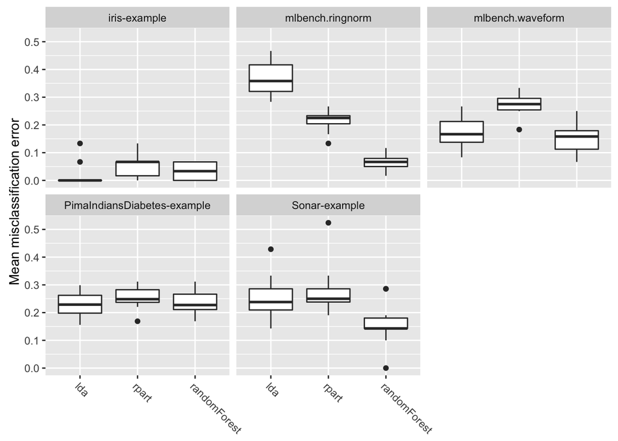

```r
plotBMRBoxplots(bmr, measure = mmce) + facet_wrap(~ task.id, nrow = 2)
```

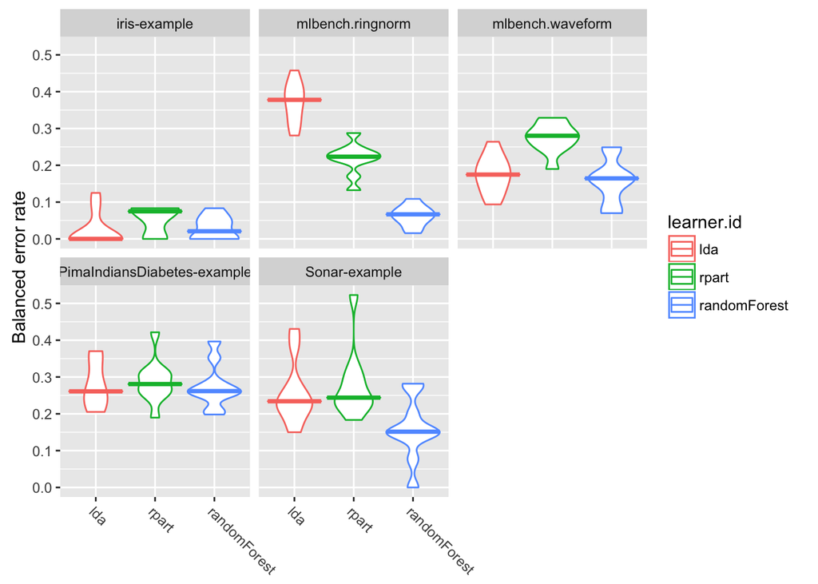

```r
plotBMRBoxplots(bmr, measure = ber, style = "violin") + aes(color = learner.id) +
  facet_wrap(~ task.id, nrow = 2)
```

The aggregated measure score on the test set (e.g. `mmce.test.mean`) is retrieved from the `benchmark` output for each learner and task and displayed through `plotBMRSummary`. By default the first measure is used. Note that the argument `jitter = 0.05` is a vertical distance added between points to prevent overplotting.

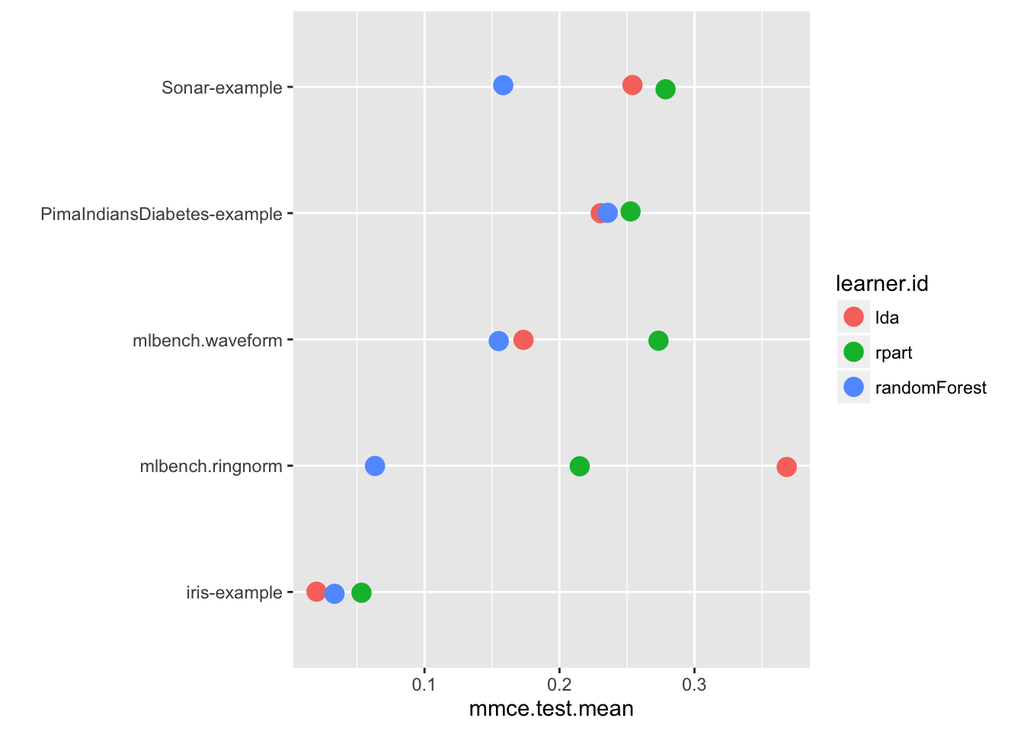

```r
plotBMRSummary(bmr)
```

Clearly, functionality showing the relative performance is of interest and what we are usually after with the benchmark experiments. The function `convertBMRToRankMatrix` calculates the rank based on a selected learner aggregated performance measure.

```r
m <- convertBMRToRankMatrix(bmr, measure = mmce)
m
```

```
##              iris-example mlbench.ringnorm mlbench.waveform
## lda                     1                3                2
## rpart                   3                2                3
## randomForest            2                1                1
##              PimaIndiansDiabetes-example Sonar-example
## lda                                    1             2
## rpart                                  3             3
## randomForest                           2             1
```

Alternatively, we can visualize the ranking results as a bar chart using `plotBMRRanksAsBarChart`. The ranks are displayed from best to worst on the horizontal axis and the tasks are shown on the vertical axis.

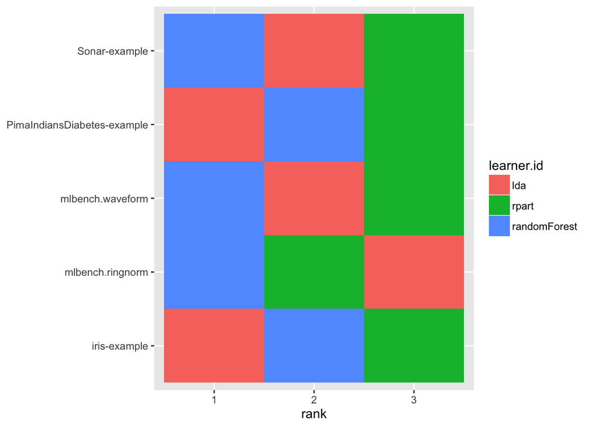

```r
plotBMRRanksAsBarChart(bmr, pos = "tile")
```

#### Hypothesis tests

Hypothesis tests can be used to conclude whether there is a significant difference between the performance of the various learners. While parametric hypothesis tests may have more power over nonparametric tests, they make assumptions about the underlying distributions from which the sample was drawn from which often means that, in order for the results to be at all reliable, we would need many data sets to show significance differences at reasonable significance levels. The mlr package provides the **Overall Friedman test** and the **Friedman-Nemenyi post hoc test**.

The Friedman test is the nonparametric alternative to a one-way ANOVA with repeated measures. We use it to compare three or more learners where the data used is the same in each learning algorithm. Unlike the ANOVA which requires the sample is drawn from a normal distribution and equal variances of the residuals, the Friedman test is free from such restrictions (but, as mentioned above, less powerful). The hypotheses for the comparison are $H_0$: The distributions (whatever they are) are the same across repeated measures and $H_1$: The distributions across repeated measures are different.

```r
friedmanTestBMR(bmr)
```

```
##
##  Friedman rank sum test
##
## data:  mmce.test.mean and learner.id and task.id
## Friedman chi-squared = 5.2, df = 2, p-value = 0.07427
```

Next, if the Friedman test results show a significant $p$-value (depending on the significance level you set i.e. $p$ < $\alpha$ for significance), then this would mean that we can reject the null that all learners perform the same but at this point we don’t know which ones are superior. Therefore, our next step will be to try and find out which pairs of our groups are significantly different then each other with a post hoc analysis. We carry this out with `friedmanPostHocTestBMR`. The following `R` code demonstrates this with a choice of a significance level of 0.1.

```r
friedmanPostHocTestBMR(bmr, p.value = 0.1)
```

```
##
##  Pairwise comparisons using Nemenyi multiple comparison test
##              with q approximation for unreplicated blocked data
##
## data:  mmce.test.mean and learner.id and task.id
##
##              lda   rpart
## rpart        0.254 -
## randomForest 0.802 0.069
##
## P value adjustment method: none
```

The results show that a significance level of 0.1, we can reject the null that there exists no performance difference between `rpart` and `randomForest`.

#### Custom plots

Examples of custom plots using the objects returned by `getBMRPerformances` and `getBMRAggrPerformances`.

**Density plots**

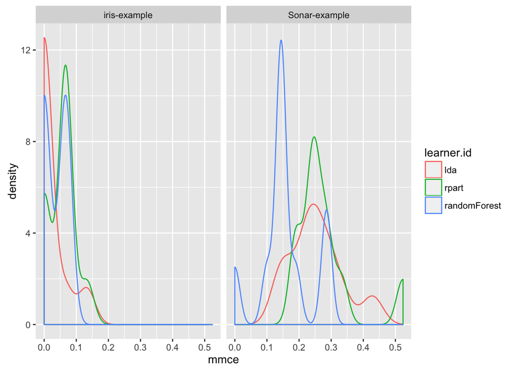

```r
perf <- getBMRPerformances(bmr, as.df = TRUE)
qplot(mmce, colour = learner.id, facets = . ~ task.id,
data = perf[perf$task.id %in% c("iris-example", "Sonar-example"), ],
geom = "density")
```

In the following `R` code, we reshape the `perf` data frame by keeping the variables `task.id`, `learner.id`, and `iter` and collect all measures into a single column (`variable`) and their corresponding values in a second column (`value`).

```r
head(perf)
```

```
##        task.id learner.id iter       mmce        ber timetrain
## 1 iris-example        lda    1 0.00000000 0.00000000     0.003
## 2 iris-example        lda    2 0.00000000 0.00000000     0.002
## 3 iris-example        lda    3 0.00000000 0.00000000     0.003
## 4 iris-example        lda    4 0.00000000 0.00000000     0.002
## 5 iris-example        lda    5 0.13333333 0.12500000     0.003
## 6 iris-example        lda    6 0.06666667 0.08333333     0.003
```

```r
perfdf <- reshape2::melt(perf, id.vars = c("task.id", "learner.id", "iter"))
head(perfdf)
```

```
##        task.id learner.id iter variable      value
## 1 iris-example        lda    1     mmce 0.00000000
## 2 iris-example        lda    2     mmce 0.00000000
## 3 iris-example        lda    3     mmce 0.00000000
## 4 iris-example        lda    4     mmce 0.00000000
## 5 iris-example        lda    5     mmce 0.13333333
## 6 iris-example        lda    6     mmce 0.06666667
```

We plot boxplots for `mmce` and `timetrain` for each task.

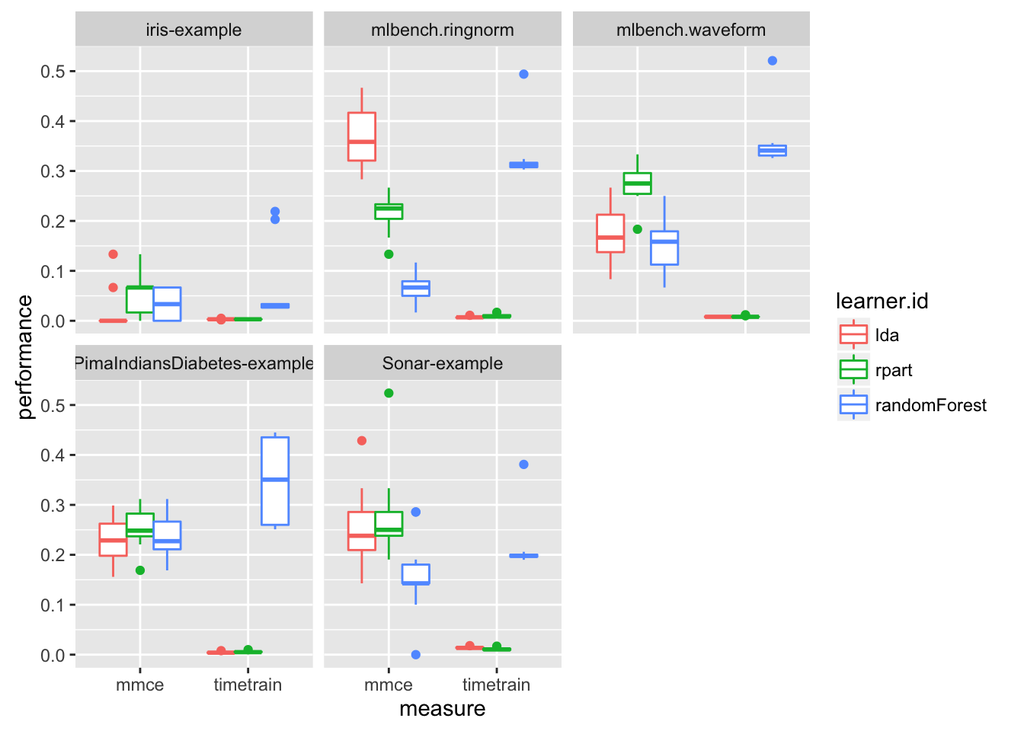

```r
perfdf <- perfdf[perfdf$variable != "ber", ]
qplot(variable, value, data = perfdf, colour = learner.id, geom = "boxplot",
      xlab = "measure", ylab = "performance") +
  facet_wrap(~ task.id, nrow = 2)
```

Further insight may be gained on learner performance by comparing the performance in each fold for a particular task; one learner could be performing exceptionally well in a single iteration while another may be performing exceptionally bad. We do this on the sonar data below by collecting the misclassification errors computed by the three learners we used.

```r
perf <- getBMRPerformances(bmr, task.ids = "Sonar-example", as.df = TRUE)
df <- reshape2::melt(perf, id.vars = c("task.id", "learner.id", "iter"))
df <- df[df$variable == "mmce",]
df <- reshape2::dcast(df, task.id + iter ~ variable + learner.id)
head(df)
```

```
##         task.id iter  mmce_lda mmce_rpart mmce_randomForest
## 1 Sonar-example    1 0.1500000  0.2500000         0.1000000
## 2 Sonar-example    2 0.2857143  0.2380952         0.1904762
## 3 Sonar-example    3 0.2380952  0.2857143         0.1428571
## 4 Sonar-example    4 0.2380952  0.2380952         0.2857143
## 5 Sonar-example    5 0.1428571  0.1904762         0.1428571
## 6 Sonar-example    6 0.2857143  0.3333333         0.2857143
```

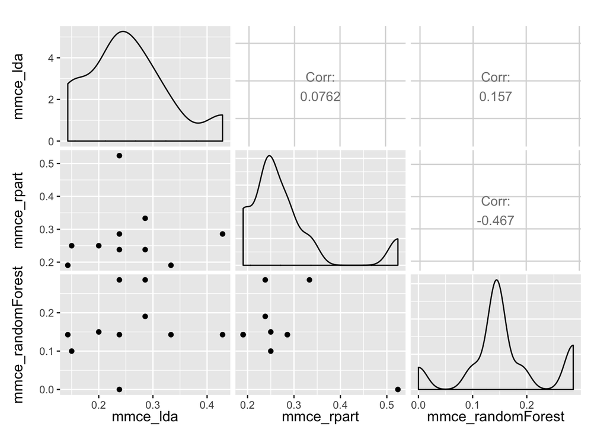

```r
# scatterplot matrix
GGally::ggpairs(df, 3:5)
```

### Parallelization

A number of instances are parallelizable with mlr. Parallelization is activated using `parallelMap::parallelStart`, the first loop mlr encounters (which is parallel executable) will be automatically parallelized.

```r
# parallelStartSocket(2)
parallelStartMulticore(cpus = 2) # better for macosx?
```

```
## Starting parallelization in mode=multicore with cpus=2.
```

```r
rdesc <- makeResampleDesc("CV", iters = 3)
r <- resample("classif.lda", task = iris.task, rdesc)
```

```
## Mapping in parallel: mode = multicore; cpus = 2; elements = 3.
```

```
## [Resample] Result: mmce.test.mean=0.04
```

```r
parallelStop()
```

```
## Stopped parallelization. All cleaned up.
```

The `parallelStart` functions have an optional argument `levels`; by setting it, we can control which level gets parallelized. For instance, we may be running a few benchmark experiments which use an elaborate resampling description. In such a case, it would be best to have the resampling parallelized and not the benchmark so we could set `level = "mlr.resample"` in the `parallelStart` function. Not all levels are supported, the current version (2.8) supports `mlr.benchmark`, `mlr.resample`, `mlr.selectFeatures`, and `mlr.tuneParams`.

For custom learners, they need to be exported to the slave before calling the `parallelStart` functions:

`parallelExport("trainLearner.regr.<myregrlearner>", "predictLearner.regr.<myregrlearner>")`

#### Visualizations

We have already seen various `generate` functions within mlr which generate data that can then be used for plotting and visualization using `plotting` functions. Let us revisit the binary classification task with the sonar data set and plot the classifier performance against the boundary decision threshold.

```r
lrn <- makeLearner("classif.lda", predict.type = "prob")
n <- getTaskSize(sonar.task)
mod <- mlr::train(learner = lrn, task = sonar.task, subset = seq(1, n, by = 2))
pred <- predict(mod, task = sonar.task, subset = seq(2, n, by = 2))
d <- generateThreshVsPerfData(pred, measures = list(fpr, fnr, mmce))
head(d$data)
```

```
##         fpr       fnr      mmce  threshold
## 1 1.0000000 0.0000000 0.4615385 0.00000000
## 2 0.3541667 0.1964286 0.2692308 0.01010101
## 3 0.3333333 0.2321429 0.2788462 0.02020202
## 4 0.3333333 0.2321429 0.2788462 0.03030303
## 5 0.3333333 0.2321429 0.2788462 0.04040404
## 6 0.3125000 0.2321429 0.2692308 0.05050505
```

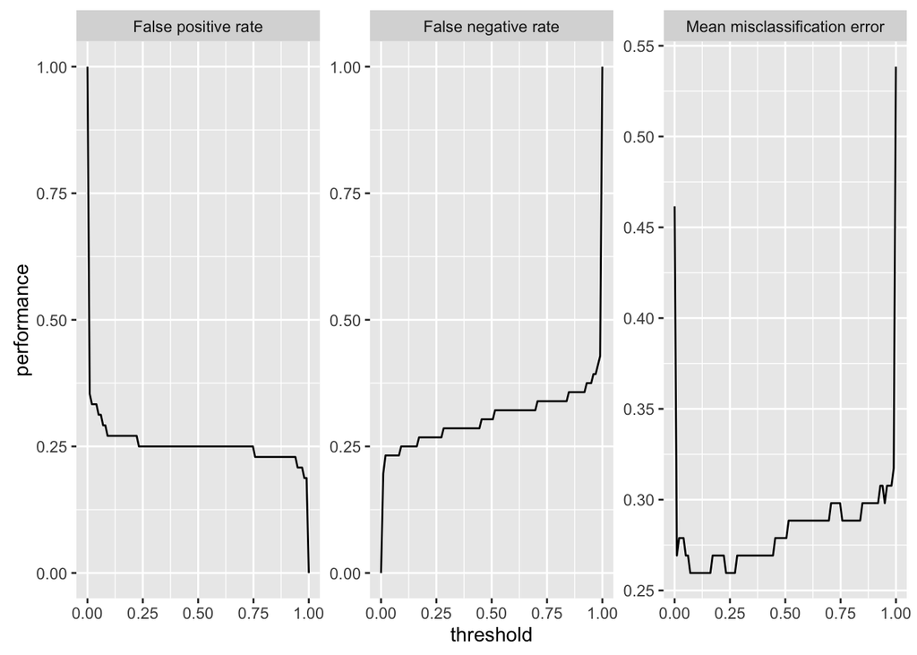

```r
plotThreshVsPerf(d) #GGVIS is also possible but currently experimental
```

Alternatively, the plot can be manually created using the data generated from the `generate` function. Using ggplot we show this below.

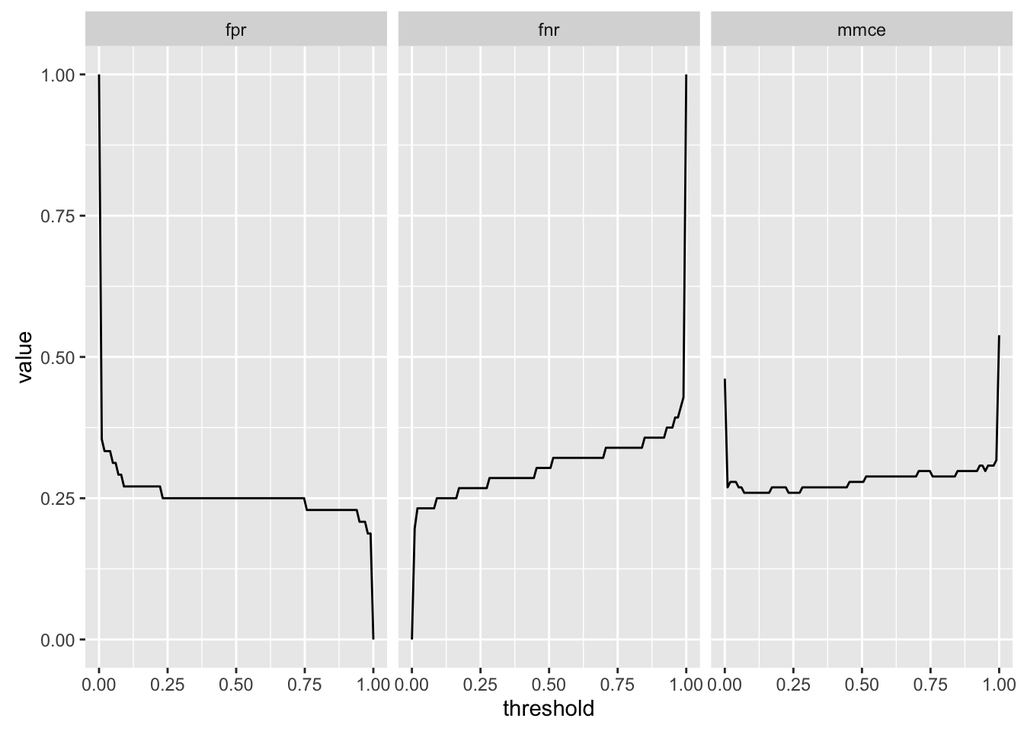

```r
dnew <- reshape2::melt(data = d$data, id.vars= c("threshold"))
ggplot(data = dnew, aes(threshold, value)) + geom_line() + facet_grid(. ~ variable,
                                                                      scales = "free_y")
```

In this second example, we `generate` partial data on what we are interested in visualizing from the fitted model using `generatePartialPredictionData` and then create plot using `plotPartialPrediction`.

```r
sonar <- getTaskData(sonar.task)
pd <- generatePartialPredictionData(mod, input = sonar, features = "V11")
plt <- plotPartialPrediction(pd)
head(plt$data)
```

```
##   Class Probability Feature     Value
## 1     M   0.9295997     V11 0.7342000
## 2     M   0.9084961     V11 0.6558333
## 3     M   0.8792694     V11 0.5774667
## 4     M   0.8232852     V11 0.4991000
## 5     M   0.7387962     V11 0.4207333
## 6     M   0.6557857     V11 0.3423667
```

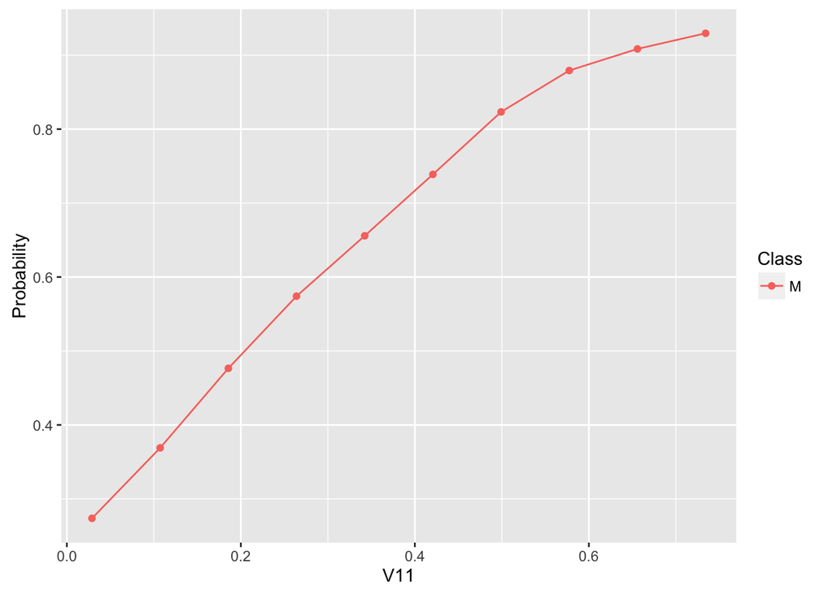

```r
plt
```

## Advanced

### Wrappers

#### Introductory example

It is possible to add pre-processing, missing values imputation, tuning, feature selection and other functionality to a learner through the use of wrappers. Each time a wrapper is used around an mlr learner, a new learner is returned and this procedure can be repeated many times.

As a first example we use a bagging wrapper to create a random forest which supports weights and compare it to the unwrapped learner (`base.lrn` below).

```r
data(iris)
task <- makeClassifTask(data = iris, target = "Species", weights = as.integer(iris$Species))
base.lrn <- makeLearner("classif.rpart")
```

The `makeBaggingWrapper` function takes as inputs the learner we want wrapped, the number of iterations which is the number of fitted models in bagging (for `rpart` learner, this would be `ntree` = N base learners), an option for sampling with/without replacement, proportion of randomly selected features (this would be the equivalent of `mtry`, here we set it at .5)

```r
wrapped.lrn <- makeBaggingWrapper(learner = base.lrn, bw.iters = 100, bw.feats = 0.5 )
print(wrapped.lrn)
```

```
## Learner classif.rpart.bagged from package rpart
## Type: classif
## Name: ; Short name:
## Class: BaggingWrapper
## Properties: twoclass,multiclass,missings,numerics,factors,ordered,prob,weights
## Predict-Type: response
## Hyperparameters: xval=0,bw.iters=100,bw.feats=0.5
```

Next, we run a `benchmark` experiment with the list of learners comprised of the base and wrapped learners. Note that the default resampling strategy is 10-fold cross-validation.

```r
bmr <- benchmark(learners = list(base.lrn, wrapped.lrn), task = task)
```

```
## Task: iris, Learner: classif.rpart
```

```
## [Resample] cross-validation iter: 1
```

```
## [Resample] cross-validation iter: 2
```

```
## [Resample] cross-validation iter: 3
```

```
## [Resample] cross-validation iter: 4
```

```
## [Resample] cross-validation iter: 5
```

```
## [Resample] cross-validation iter: 6
```

```
## [Resample] cross-validation iter: 7
```

```
## [Resample] cross-validation iter: 8
```

```
## [Resample] cross-validation iter: 9
```

```
## [Resample] cross-validation iter: 10
```

```
## [Resample] Result: mmce.test.mean=0.0867
```

```
## Task: iris, Learner: classif.rpart.bagged
```

```
## [Resample] cross-validation iter: 1
```

```
## [Resample] cross-validation iter: 2
```

```
## [Resample] cross-validation iter: 3
```

```
## [Resample] cross-validation iter: 4
```

```
## [Resample] cross-validation iter: 5
```

```
## [Resample] cross-validation iter: 6
```

```
## [Resample] cross-validation iter: 7
```

```
## [Resample] cross-validation iter: 8
```

```
## [Resample] cross-validation iter: 9
```

```
## [Resample] cross-validation iter: 10
```

```
## [Resample] Result: mmce.test.mean=0.0533
```

```r
bmr
```

```
##   task.id           learner.id mmce.test.mean
## 1    iris        classif.rpart     0.08666667
## 2    iris classif.rpart.bagged     0.05333333
```

We may choose to carry out hyperparameter tuning to hopefully improve on the performance of the new learner. The function `makeTuneWrapper` fuses a learner with a search strategy to select its hyperparameters. This is set in effect when `train` is called (see below). First the algorithm for the hyperparameter optimization must be chosen - this is done via the `makeTuneControl` functions. A grid algorithm is traditional but it may be computationally expensive in high-dimensional spaces. In this example we only explore a small parameter space (we tune `minsplit` and `bw.feats`) with *random search*. The `minsplit` parameter is the minimum number of observations that must exist in a node in order for a split to be attempted and `bw.feats` was discussed above. In the random search, we choose to have sampled settings randomly selected 10 times (`maxit = 10`)

```r
ctrl <- makeTuneControlRandom(maxit = 10)
rdesc <- makeResampleDesc("CV", iters = 3)
par.set <- makeParamSet(makeIntegerParam("minsplit", lower = 1, upper = 10),
                        makeNumericParam("bw.feats", lower = 0.25, upper = 1))

tuned.lrn <- makeTuneWrapper(learner = wrapped.lrn, resampling = rdesc,
                             measures = mmce, par.set = par.set, control = ctrl)
print(tuned.lrn)
```

```
## Learner classif.rpart.bagged.tuned from package rpart
## Type: classif
## Name: ; Short name:
## Class: TuneWrapper
## Properties: numerics,factors,ordered,missings,weights,prob,twoclass,multiclass
## Predict-Type: response
## Hyperparameters: xval=0,bw.iters=100,bw.feats=0.5
```

Now we have a learner object like before but this learner internally used `tuneParams` such as when called with `train`, the search strategy and resampling are invoked to choose an optimal set of parameters. The output from `train` is a tuned, bagged learner.

```r
lrn <- mlr::train(learner = tuned.lrn, task = task)
```

```
## [Tune] Started tuning learner classif.rpart.bagged for parameter set:
```

```
##             Type len Def    Constr Req Tunable Trafo
## minsplit integer   -   -   1 to 10   -    TRUE     -
## bw.feats numeric   -   - 0.25 to 1   -    TRUE     -
```

```
## With control class: TuneControlRandom
```

```
## Imputation value: 1
```

```
## [Tune-x] 1: minsplit=6; bw.feats=0.432
```

```
## [Tune-y] 1: mmce.test.mean=0.04; time: 0.1 min; memory: 208Mb use, 546Mb max
```

```
## [Tune-x] 2: minsplit=10; bw.feats=0.449
```

```
## [Tune-y] 2: mmce.test.mean=0.04; time: 0.1 min; memory: 208Mb use, 546Mb max
```

```
## [Tune-x] 3: minsplit=4; bw.feats=0.429
```

```
## [Tune-y] 3: mmce.test.mean=0.04; time: 0.1 min; memory: 208Mb use, 546Mb max
```

```
## [Tune-x] 4: minsplit=4; bw.feats=0.771
```

```
## [Tune-y] 4: mmce.test.mean=0.0467; time: 0.1 min; memory: 208Mb use, 546Mb max
```

```
## [Tune-x] 5: minsplit=2; bw.feats=0.803
```

```
## [Tune-y] 5: mmce.test.mean=0.0467; time: 0.1 min; memory: 208Mb use, 546Mb max
```

```
## [Tune-x] 6: minsplit=5; bw.feats=0.569
```

```
## [Tune-y] 6: mmce.test.mean=0.0467; time: 0.1 min; memory: 208Mb use, 546Mb max
```

```
## [Tune-x] 7: minsplit=8; bw.feats=0.483
```

```
## [Tune-y] 7: mmce.test.mean=0.0533; time: 0.1 min; memory: 208Mb use, 546Mb max
```

```
## [Tune-x] 8: minsplit=10; bw.feats=0.362
```

```
## [Tune-y] 8: mmce.test.mean=0.0733; time: 0.1 min; memory: 208Mb use, 546Mb max
```

```
## [Tune-x] 9: minsplit=8; bw.feats=0.268
```

```
## [Tune-y] 9: mmce.test.mean=0.06; time: 0.1 min; memory: 208Mb use, 546Mb max
```

```
## [Tune-x] 10: minsplit=8; bw.feats=0.62
```

```
## [Tune-y] 10: mmce.test.mean=0.0467; time: 0.1 min; memory: 208Mb use, 546Mb max
```

```
## [Tune] Result: minsplit=10; bw.feats=0.449 : mmce.test.mean=0.04
```

```r
print(lrn)
```

```
## Model for learner.id=classif.rpart.bagged.tuned; learner.class=TuneWrapper
## Trained on: task.id = iris; obs = 150; features = 4
## Hyperparameters: xval=0,bw.iters=100,bw.feats=0.5
```

```r
getTuneResult(lrn)
```

```
## Tune result:
## Op. pars: minsplit=10; bw.feats=0.449
## mmce.test.mean=0.04
```

#### Data preprocessing

The mlr package offers many options for data preprocessing. Some of them are directly applied to a task to modify it. These include `capLargeValues`, `createDummyFeatures` (for factor variables), `dropFeatures`, `joinClassLevels`, `mergeSmallFactorLevels`, `normalizeFeatures`, `removeConstantFeatures`, and `subsetTask` which are all pretty self explanatory from their name.

With the mlr wrapper functionality, the preprocessing steps are done at the time the learner is trained or predictions are made. This is important as it avoids the mistake of integrating processing steps which are data-dependent on the whole data set while the learner is trained only on training/test sets. A more honest performance of the learner is obtained if all preprocessing steps are included in the resampling. This is automatically done when fusing a learner with preprocessing.

`makePreprocWrapperCaret` permits access to all preprocessing options offered by `caret`’s `preProcess` function while`makePreprocWrapper` is used when writing custom preprocessing methods by defining the actions to be taken before training and before prediction. With these two functions, the preprocessing steps then belong to the learner. This is in contrast to the functions defined above (e.g `normalizeFeatures`) which alters the task. So, here, the task remains unchanged, preprocessing is done for every pair of training/test sets in resampling and not globally on the whole data set, and any parameters pertinent to preprocessing can be tuned with the learner’s parameters.

Firstly, the usage of`makePreprocWrapperCaret` is similar to `caret`’s `preProcess` in the sense that it takes almost all of the formal arguments though their names are prefixed by `ppc.`, e.g. `knnImpute` becomes `ppc.knnImpute`. Secondly, there is no `method` argument; instead, the preprocessing options are passed as individual logical arguments, i.e. `pcc.knnImpute = TRUE`.

For knn imputation and pca in caret:

`preProcess(x, method = c("knnImpute", "pca"), pcaComp = 10)`

With the mlr wrapper:

`makePreprocWrapperCaret(learner, ppc.knnImpute = TRUE, ppc.pca = TRUE, ppc.pcaComp = 10)`

We show an example where we apply PCA on the sonar data (this poses a binary classification problem with 208 obs and 60 features) for dimensionality reduction. The `makePreprocWrapperCaret` function below is used to fuse quadratic discriminant analysis with PCA preprocessing where we set the threshold for PCA to retain 90 % (cumulative percent) of variance. Note that the data is automatically standardized prior to applying PCA.

```r
lrn <- makePreprocWrapperCaret(learner = "classif.qda", ppc.pca = TRUE, ppc.thresh = 0.9)
lrn
```

```
## Learner classif.qda.preproc from package MASS
## Type: classif
## Name: ; Short name:
## Class: PreprocWrapperCaret
## Properties: twoclass,multiclass,numerics,factors,prob
## Predict-Type: response
## Hyperparameters: ppc.BoxCox=FALSE,ppc.YeoJohnson=FALSE,ppc.expoTrans=FALSE,ppc.center=TRUE,ppc.scale=TRUE,ppc.range=FALSE,ppc.knnImpute=FALSE,ppc.bagImpute=FALSE,ppc.medianImpute=FALSE,ppc.pca=TRUE,ppc.ica=FALSE,ppc.spatialSign=FALSE,ppc.thresh=0.9,ppc.na.remove=TRUE,ppc.k=5,ppc.fudge=0.2,ppc.num…
```

Now, that we have a wrapped learner, calling `train` with the task will train with the principal components returned after PCA has been applied.

```r
mod <- mlr::train(lrn, sonar.task)
mod$learner.model
```

```
## Model for learner.id=classif.qda; learner.class=classif.qda
## Trained on: task.id = Sonar-example; obs = 208; features = 22
## Hyperparameters:
```

```r
# or, for more info:
getLearnerModel(model = mod, more.unwrap = TRUE)
```

```
## Call:
## qda(f, data = getTaskData(.task, .subset, recode.target = "drop.levels"))
##
## Prior probabilities of groups:
##         M         R
## 0.5336538 0.4663462
##
## Group means:
##          PC1        PC2        PC3         PC4         PC5         PC6
## M  0.5976122 -0.8058235  0.9773518  0.03794232 -0.04568166 -0.06721702
## R -0.6838655  0.9221279 -1.1184128 -0.04341853  0.05227489  0.07691845
##          PC7         PC8        PC9       PC10        PC11          PC12
## M  0.2278162 -0.01034406 -0.2530606 -0.1793157 -0.04084466 -0.0004789888
## R -0.2606969  0.01183702  0.2895848  0.2051963  0.04673977  0.0005481212
##          PC13       PC14        PC15        PC16        PC17        PC18
## M -0.06138758 -0.1057137  0.02808048  0.05215865 -0.07453265  0.03869042
## R  0.07024765  0.1209713 -0.03213333 -0.05968671  0.08528994 -0.04427460
##          PC19         PC20        PC21         PC22
## M -0.01192247  0.006098658  0.01263492 -0.001224809
## R  0.01364323 -0.006978877 -0.01445851  0.001401586
```

Finally, we carry out a benchmark experiment to explore whether preprocessing with PCA has improved the performance of qda. We choose `stratify = TRUE` in resampling due to each class being represented by a small number of observations.

```r
rin <- makeResampleInstance("CV", iters = 3, stratify = TRUE, task = sonar.task)
bmr <- benchmark(learners = list(makeLearner("classif.qda"), lrn), tasks = sonar.task, resamplings = rin, show.info = FALSE)
bmr
```

```
##         task.id          learner.id mmce.test.mean
## 1 Sonar-example         classif.qda      0.4035887
## 2 Sonar-example classif.qda.preproc      0.1733609
```

So far so good; it seems that PCA preprocessing is beneficial for the qda. However, the `thresh` value was chosen somewhat arbitrarily and resulted in 22 principal components. Perhaps with further tuning of the parameter, we can improve the performance of qda. Preprocessing and learner parameters can be tuned jointly. Calling `getParamSet` on the wrapped learner gives us all options.

```r
getParamSet(lrn)
```

```
##                      Type len     Def                      Constr Req
## ppc.BoxCox        logical   -   FALSE                           -   -
## ppc.YeoJohnson    logical   -   FALSE                           -   -
## ppc.expoTrans     logical   -   FALSE                           -   -
## ppc.center        logical   -    TRUE                           -   -
## ppc.scale         logical   -    TRUE                           -   -
## ppc.range         logical   -   FALSE                           -   -
## ppc.knnImpute     logical   -   FALSE                           -   -
## ppc.bagImpute     logical   -   FALSE                           -   -
## ppc.medianImpute  logical   -   FALSE                           -   -
## ppc.pca           logical   -   FALSE                           -   -
## ppc.ica           logical   -   FALSE                           -   -
## ppc.spatialSign   logical   -   FALSE                           -   -
## ppc.thresh        numeric   -    0.95                    0 to Inf   -
## ppc.pcaComp       integer   -       -                    1 to Inf   -
## ppc.na.remove     logical   -    TRUE                           -   -
## ppc.k             integer   -       5                    1 to Inf   -
## ppc.fudge         numeric   -     0.2                    0 to Inf   -
## ppc.numUnique     integer   -       3                    1 to Inf   -
## method           discrete   -  moment            moment,mle,mve,t   -
## nu                numeric   -       5                    2 to Inf   Y
## predict.method   discrete   - plug-in plug-in,predictive,debiased   -
##                  Tunable Trafo
## ppc.BoxCox          TRUE     -
## ppc.YeoJohnson      TRUE     -
## ppc.expoTrans       TRUE     -
## ppc.center          TRUE     -
## ppc.scale           TRUE     -
## ppc.range           TRUE     -
## ppc.knnImpute       TRUE     -
## ppc.bagImpute       TRUE     -
## ppc.medianImpute    TRUE     -
## ppc.pca             TRUE     -
## ppc.ica             TRUE     -
## ppc.spatialSign     TRUE     -
## ppc.thresh          TRUE     -
## ppc.pcaComp         TRUE     -
## ppc.na.remove       TRUE     -
## ppc.k               TRUE     -
## ppc.fudge           TRUE     -
## ppc.numUnique       TRUE     -
## method              TRUE     -
## nu                  TRUE     -
## predict.method      TRUE     -
```

In what follows, we tune the number of principal components (instead of `ppc.thresh`) and we try two different ways to estimate the posterior probabilities in qda: *plug-in estimates* and *unbiased estimates*. This is controled via the `predict.method` parameter. The hyperparameter tuning is done via a *grid search* this time with a resolution of 10 (consider finer resolutions in real problems).

```r
ps <- makeParamSet(
  makeIntegerParam("ppc.pcaComp", lower = 1, upper = getTaskNFeats(sonar.task)),
  makeDiscreteParam("predict.method", values = c("plug-in", "debiased"))
)

ctrl <- makeTuneControlGrid(resolution = 10)
res <- tuneParams(lrn, sonar.task, rin, par.set = ps, control = ctrl, show.info = FALSE)
res
```

```
## Tune result:
## Op. pars: ppc.pcaComp=14; predict.method=plug-in
## mmce.test.mean=0.168
```

The following example shows how to create a custom preprocessing wrapper using `makePreprocWrapper` which adds a scaling option to a learner by coupling it with the function `scale` (note this is actually possible through `makePreprocWrapperCaret`). Since wrappers are implemented using a *train* and *predict* method, we specify custom train and predict functions. The *train* function has to return a list with the preprocessed data set (`$data`) and an element which stores the information required to preprocess the data before prediction (`$control`). In our example, `$control` stores the scaling parameters which are to be used in the prediction.

```r
trainfun <- function(data, target, args = list(center, scale)){
  cns <- colnames(data)
  # identify num data - exclude target
  nums <- setdiff(cns[sapply(data, is.numeric)], target)
  # extract numerical feats
  x <- as.matrix(data[, nums, drop = FALSE])
  x <- scale(x, center = args$center, scale = args$scale)
  # store the scaling parameters in control, needed to preprocess the data before preds.
  control <- args
  if (is.logical(control$center) && control$center)
    control$center = attr(x, "scaled:center")
  if (is.logical(control$scale) && control$scale)
    control$scale = attr(x, "scaled:scale")
  # recombine the data
  data <- data[, setdiff(cns, nums), drop = FALSE]
  data <- cbind(data, as.data.frame(x))
  return(list(data = data, control = control))
}
```

Next, the *predict* function takes in the data (without target variable), the name of the target variable, the`args` that were passed to `trainfun` and the `control` object returned by `trainfun`.

```r
predictfun <- function(data, target, args, control){
  cns <- colnames(data)
  nums <- cns[sapply(data, is.numeric)]
  x <- as.matrix(data[, nums, drop = FALSE])
  x <- scale(x, center = control$center, scale = control$scale)
  data <- data[, setdiff(cns, nums), drop = FALSE]
  data <- cbind(data, as.data.frame(x))
  return(data)
}
```

Now we are going to use the functions we specified in a preprocessing wrapper. We use a regression neural network which does not have a scaling option and couple it with our own center + scale.

```r
lrn <- makeLearner("regr.nnet", trace = FALSE, decay = 1e-02)
lrn <- makePreprocWrapper(lrn, train = trainfun, predict = predictfun,
                          par.vals = list(center = TRUE, scale = TRUE))
lrn
```

```
## Learner regr.nnet.preproc from package nnet
## Type: regr
## Name: ; Short name:
## Class: PreprocWrapper
## Properties: numerics,factors,weights
## Predict-Type: response
## Hyperparameters: size=3,trace=FALSE,decay=0.01
```

We now compare the performance of a `nnet` with and without scaling using the cross-validated mean squared error as a measure.

```r
rdesc <- makeResampleDesc("CV", iters = 3)
r <- resample(lrn, bh.task, rdesc, measures = mse, show.info = FALSE)
r
```

```
## Resample Result
## Task: BostonHousing-example
## Learner: regr.nnet.preproc
## mse.aggr: 25.05
## mse.mean: 25.05
## mse.sd: 8.63
## Runtime: 0.094934
```

And without scaling.

```r
lrn <- makeLearner("regr.nnet", trace = FALSE, decay = 1e-02)
r <- resample(lrn, bh.task, rdesc, measures = mse, show.info = FALSE)
r
```

```
## Resample Result
## Task: BostonHousing-example
## Learner: regr.nnet
## mse.aggr: 58.09
## mse.mean: 58.09
## mse.sd: 29.99
## Runtime: 0.0575051
```

#### Joint tuning of preprocessing and learner parameters

Usually we have some idea of what preprocessing we want to apply but it’s not clear what options work best for each algorithm. It is possible to tune the preprocesssing and learner parameters as we have previously done.

```r
lrn <- makeLearner("regr.nnet", trace = FALSE)
lrn <- makePreprocWrapper(lrn, train = trainfun, predict = predictfun,
                          par.set = makeParamSet(
                            makeLogicalLearnerParam("center"),
                            makeLogicalLearnerParam("scale")
                          ),
                          par.vals = list(center = TRUE, scale = TRUE)
                          )
lrn
```

```
## Learner regr.nnet.preproc from package nnet
## Type: regr
## Name: ; Short name:
## Class: PreprocWrapper
## Properties: numerics,factors,weights
## Predict-Type: response
## Hyperparameters: size=3,trace=FALSE,center=TRUE,scale=TRUE
```

```r
getParamSet(lrn)
```

```
##             Type len    Def      Constr Req Tunable Trafo
## center   logical   -      -           -   -    TRUE     -
## scale    logical   -      -           -   -    TRUE     -
## size     integer   -      3    0 to Inf   -    TRUE     -
## maxit    integer   -    100    1 to Inf   -    TRUE     -
## linout   logical   -  FALSE           -   Y    TRUE     -
## entropy  logical   -  FALSE           -   Y    TRUE     -
## softmax  logical   -  FALSE           -   Y    TRUE     -
## censored logical   -  FALSE           -   Y    TRUE     -
## skip     logical   -  FALSE           -   -    TRUE     -
## rang     numeric   -    0.7 -Inf to Inf   -    TRUE     -
## decay    numeric   -      0    0 to Inf   -    TRUE     -
## Hess     logical   -  FALSE           -   -    TRUE     -
## trace    logical   -   TRUE           -   -   FALSE     -
## MaxNWts  integer   -   1000    1 to Inf   -    TRUE     -
## abstoll  numeric   - 0.0001 -Inf to Inf   -    TRUE     -
## reltoll  numeric   -  1e-08 -Inf to Inf   -    TRUE     -
```

We now tune via a grid search the decay parameter for the learner as well as the center and scale parameters for the preprocessing.

```r
rdesc <- makeResampleDesc("Holdout")
ps <- makeParamSet(
  makeLogicalParam("center"),
  makeLogicalParam("scale"),
  makeDiscreteParam("decay", c(0, 0.05, 0.1))
)
ctrl <- makeTuneControlGrid()
res <- tuneParams(lrn, bh.task, rdesc, par.set = ps, control = ctrl, show.info = FALSE)
res
```

```
## Tune result:
## Op. pars: center=FALSE; scale=TRUE; decay=0.1
## mse.test.mean=8.95
```

```r
as.data.frame(res$opt.path)
```

```
##    center scale decay mse.test.mean dob eol error.message exec.time
## 1    TRUE  TRUE     0     17.830530   1  NA          <NA>     0.031
## 2   FALSE  TRUE     0     83.387119   2  NA          <NA>     0.015
## 3    TRUE FALSE     0     66.564141   3  NA          <NA>     0.018
## 4   FALSE FALSE     0     83.387119   4  NA          <NA>     0.017
## 5    TRUE  TRUE  0.05     13.830167   5  NA          <NA>     0.036
## 6   FALSE  TRUE  0.05      9.457274   6  NA          <NA>     0.032
## 7    TRUE FALSE  0.05     54.261502   7  NA          <NA>     0.036
## 8   FALSE FALSE  0.05     14.007771   8  NA          <NA>     0.029
## 9    TRUE  TRUE   0.1     26.572742   9  NA          <NA>     0.030
## 10  FALSE  TRUE   0.1      8.949573  10  NA          <NA>     0.031
## 11   TRUE FALSE   0.1     50.246538  11  NA          <NA>     0.033
## 12  FALSE FALSE   0.1     51.864713  12  NA          <NA>     0.032
```

### Imputation of missing values

In the mlr package, methods of imputation of missing values include imputation by a constant (mean, median, mode or some other constant), random numbers (some distribution), or based on predictions by a supervised learner. The possibility of custom imputation methods is also available. Note that some of the learning algorithms in mlr which have the `missings` property integrated, can deal with missing values in a sensible way (i.e. not simply deleting observations). Typing `listLearners("regr", properties = "missings")[c("class", "package")]` will give info on those packages if they are installed.

We first look at a simple example making use of the function `impute` on the `airquality` data set. To further demonstrate the functionality of `impute`, we add some missing values in the `Wind` column and then coerce into a factor using `cut`.

```r
data("airquality")
airq <- airquality
ind <- sample(nrow(airquality), 10)
airq$Wind[ind] <- NA
airq$Wind <- cut(airq$Wind, c(0, 8, 16, 24))
summary(airq)
```

```
##      Ozone           Solar.R           Wind         Temp
##  Min.   :  1.00   Min.   :  7.0   (0,8]  :49   Min.   :56.00
##  1st Qu.: 18.00   1st Qu.:115.8   (8,16] :87   1st Qu.:72.00
##  Median : 31.50   Median :205.0   (16,24]: 7   Median :79.00
##  Mean   : 42.13   Mean   :185.9   NA's   :10   Mean   :77.88
##  3rd Qu.: 63.25   3rd Qu.:258.8                3rd Qu.:85.00
##  Max.   :168.00   Max.   :334.0                Max.   :97.00
##  NA's   :37       NA's   :7
##      Month            Day
##  Min.   :5.000   Min.   : 1.0
##  1st Qu.:6.000   1st Qu.: 8.0
##  Median :7.000   Median :16.0
##  Mean   :6.993   Mean   :15.8
##  3rd Qu.:8.000   3rd Qu.:23.0
##  Max.   :9.000   Max.   :31.0
##
```

```r
sapply(airq, class)
```

```
##     Ozone   Solar.R      Wind      Temp     Month       Day
## "integer" "integer"  "factor" "integer" "integer" "integer"
```

The `Ozone` and `Solar.R` variables are of class integer and the `Wind` variable is of class factor. We choose to impute the integer features by the mean and the factor feature by the mode. We also choose to create dummy variables for all integer features indicating which observations were missing.

```r
imp <- impute(airq, classes = list(integer = imputeMean(), factor = imputeMode()), dummy.classes = "integer")
head(imp$data)
```

```
##      Ozone  Solar.R   Wind Temp Month Day Ozone.dummy Solar.R.dummy
## 1 41.00000 190.0000  (0,8]   67     5   1       FALSE         FALSE
## 2 36.00000 118.0000  (0,8]   72     5   2       FALSE         FALSE
## 3 12.00000 149.0000 (8,16]   74     5   3       FALSE         FALSE
## 4 18.00000 313.0000 (8,16]   62     5   4       FALSE         FALSE
## 5 42.12931 185.9315 (8,16]   56     5   5        TRUE          TRUE
## 6 28.00000 185.9315 (8,16]   66     5   6       FALSE          TRUE
```

The function `impute` returns an object with the elements `$data` and `$desc`; the latter stores the information for the imputation. Note that “Imputed” refers to the class of features for which an imputation method was specified (here, 5 integers + 1 factor) and not the features which contain NA values. Here, the target variable was not specified. Next, let us look at a learning task example where the target variable is involved. In the `airquality` data set, we wish to predict the ozone pollution based on meteorological features. Our dataset therefore will have 4 columns: `Ozone`, `Solar.R`, `Wind`, and `Temp`.

```r
# prepare data set
# remove Day and Month
airq <- dplyr::select(airq, -c(Day, Month))
# choose first 100 obs to make up the training set
airq.train <- airq[1:100, ]
airq.test <- airq[-c(1:100), ]
```

In this example, we do the following:

1. impute missing values in `Solar.R` with random numbers drawn from an empirical distribution;
2. Use function `imputeLearner`, which allows the user to use all supervised learning algorithms integrated in mlr, to impute missing values in the factor variable `Wind`. With `imputeLearner`, we need to create a learner whose type must match the variable to be imputed. So, here we go for `classif.<learning_algorithm>` since our feature variable is a factor. Then, all columns apart from the one imputed and the target variable are used as features in the learning algorithm chosen. Note that there are algorithms that can deal with missing values so in our example, to impute `NA`’s in `Wind` using say, a classification tree, only `Temp` and `Solar.R` will be used as features in the tree. The `rpart` algorithm will be able to handle the missing values in `Solar.R`.

```r
imp <- impute(data = airq.train, target = "Ozone", cols = list(Solar.R = imputeHist(), Wind = imputeLearner(makeLearner("classif.rpart"))), dummy.cols = c("Solar.R", "Wind"))
imp$desc
```

```
## Imputation description
## Target: Ozone
## Features: 3; Imputed: 2
## impute.new.levels: TRUE
## recode.factor.levels: TRUE
## dummy.type: factor
```

```r
summary(imp$data)
```

```
##      Ozone           Solar.R           Wind         Temp
##  Min.   :  1.00   Min.   :  7.0   (0,8]  :35   Min.   :56.00
##  1st Qu.: 16.00   1st Qu.:113.8   (8,16] :59   1st Qu.:69.00
##  Median : 34.00   Median :221.5   (16,24]: 6   Median :79.50
##  Mean   : 41.59   Mean   :192.0                Mean   :76.87
##  3rd Qu.: 63.00   3rd Qu.:274.2                3rd Qu.:84.00
##  Max.   :135.00   Max.   :334.0                Max.   :93.00
##  NA's   :31
##  Solar.R.dummy Wind.dummy
##  FALSE:93      FALSE:95
##  TRUE : 7      TRUE : 5
##
##
##
##
##
```

To impute the test data the same way as the train data, we can simply use the `imp$desc` object with the function `reimpute`.

```r
airq.test.imp <- reimpute(airq.test, desc = imp$desc)
head(airq.test.imp)
```

```
##   Ozone Solar.R   Wind Temp Solar.R.dummy Wind.dummy
## 1   110     207  (0,8]   90         FALSE       TRUE
## 2    NA     222 (8,16]   92         FALSE      FALSE
## 3    NA     137 (8,16]   86         FALSE      FALSE
## 4    44     192 (8,16]   86         FALSE      FALSE
## 5    28     273 (8,16]   82         FALSE      FALSE
## 6    65     157 (8,16]   80         FALSE      FALSE
```

#### Fuse a learner with imputation

When creating a learner with `makeImputeWrapper`, before training the resulting learner, impute is applied to the training set and, subsequently, before prediction, `reimpute` is called on the test set using the `$desc` object from the training stage. In what follows, we ask for the same imputation as above and we choose a linear regression model as the learner.

```r
lrn <- makeImputeWrapper(learner = "regr.lm", cols = list(Solar.R = imputeHist(), Wind = imputeLearner(makeLearner("classif.rpart"))), dummy.cols = c("Solar.R", "Wind")
                         )
lrn
```

```
## Learner regr.lm.preproc from package stats
## Type: regr
## Name: ; Short name:
## Class: ImputeWrapper
## Properties: numerics,factors,se,weights,missings
## Predict-Type: response
## Hyperparameters:
```

To create a task, we need to delete any observations from the target variable (`Ozone`) which are missing.

```r
airq <- subset(airq, subset = !is.na(airq$Ozone))
task <- makeRegrTask(data = airq, target = "Ozone")
rdesc <- makeResampleDesc("CV", iters = 3)
r <- resample(lrn, task, rdesc, show.info = FALSE, models = TRUE)
r$aggr
```

```
## mse.test.mean
##       595.099
```

```r
lapply(r$models, getLearnerModel, more.unwrap = TRUE)
```

```
## [[1]]
##
## Call:
## stats::lm(formula = f, data = d)
##
## Coefficients:
##       (Intercept)            Solar.R         Wind(8,16]
##        -108.75925            0.06951          -22.46964
##       Wind(16,24]               Temp  Solar.R.dummyTRUE
##          -7.89778            1.94691          -24.58073
##    Wind.dummyTRUE
##          13.95148
##
##
## [[2]]
##
## Call:
## stats::lm(formula = f, data = d)
##
## Coefficients:
##       (Intercept)            Solar.R         Wind(8,16]
##         -50.35825            0.07453          -37.09466
##       Wind(16,24]               Temp  Solar.R.dummyTRUE
##         -34.44710            1.34312           -2.86339
##    Wind.dummyTRUE
##          10.29853
##
##
## [[3]]
##
## Call:
## stats::lm(formula = f, data = d)
##
## Coefficients:
##       (Intercept)            Solar.R         Wind(8,16]
##         -87.13995            0.05501          -13.82936
##       Wind(16,24]               Temp  Solar.R.dummyTRUE
##         -10.97308            1.60398           -2.54234
##    Wind.dummyTRUE
##           4.16069
```

Note that `makePreprocWrapperCaret` is also available for fusion with imputation and a learner but it is somewhat limited.

### Generic Bagging

With `makeBaggingWrapper`, it is possible to bag an mlr learner to use bagging as a technique to gain more stability. The `makeBaggingWrapper` function takes arguments which decide on the subsets to be chosen for each iteration of the bagging process. So, just like in `randomForest`, we need to train a learner on a subset of data.

- `bw.iters`: the number of subsets (samples) we want to train our learner
- `bw.replace`: logical. sample with replacement (bootstrapping) or without
- `bw.size`: percentage size of sampled bags
- `bw.feats`: percentage size of randomly selected features in bags

```r
lrn <- makeLearner("classif.rpart")
bag.lrn <- makeBaggingWrapper(lrn, bw.iters = 50, bw.replace = TRUE, bw.size = 0.8, bw.feats = 3/4)
rdesc <- makeResampleDesc("CV", iters = 5)
r <- resample(learner = lrn, task = sonar.task, resampling = rdesc, show.info = FALSE)
r$aggr
```

```
## mmce.test.mean
##      0.3267131
```

```r
rdesc <- makeResampleDesc("CV", iters = 5)
r2 <- resample(learner = bag.lrn, task = sonar.task, resampling = rdesc, show.info = FALSE)
r2$aggr
```

```
## mmce.test.mean
##      0.2260163
```

#### Changing the type of prediction

Using `setPredictType`, we can change the type of prediction. For classification problems we can either have labels (these are determined by majority voting over the preductions of the individual models) or posterior class probabilities. Note that the predict type for the base learner always has to be “response”.

```r
bag.lrn <- setPredictType(bag.lrn, predict.type = "prob")
```

In the case of a regression problem, the options for prediction type are numeric, response or standard errors.

```r
n <- getTaskSize(bh.task)
train.inds <- seq(1, n, 3)
test.inds <- setdiff(1:n, train.inds)
lrn <- makeLearner("regr.rpart")
bag.lrn <- makeBaggingWrapper(learner = lrn) # using defaults for the rest
bag.lrn <- setPredictType(bag.lrn, predict.type = "se")
mod <- mlr::train(bag.lrn, bh.task, subset = train.inds)
head(getLearnerModel(mod), 2)
```

```
## [[1]]
## Model for learner.id=regr.rpart; learner.class=regr.rpart
## Trained on: task.id = BostonHousing-example; obs = 169; features = 13
## Hyperparameters: xval=0
##
## [[2]]
## Model for learner.id=regr.rpart; learner.class=regr.rpart
## Trained on: task.id = BostonHousing-example; obs = 169; features = 13
## Hyperparameters: xval=0
```

Next we predict the response and calculate the standard deviation for each prediction:

```r
pred <- predict(mod, task = bh.task, subset = test.inds)
head(as.data.frame(pred))
```

```
##   id truth response       se
## 2  2  21.6 21.91884 1.320067
## 3  3  34.7 34.60776 3.748879
## 5  5  36.2 32.40824 3.217443
## 6  6  28.7 23.84344 0.823360
## 8  8  27.1 14.07722 3.103786
## 9  9  16.5 14.07722 3.103786
```

We can then plot the percentage of lower status of the population against the predicted response (predicted `medv`) with its calculated standard errors using `ggplot2`.

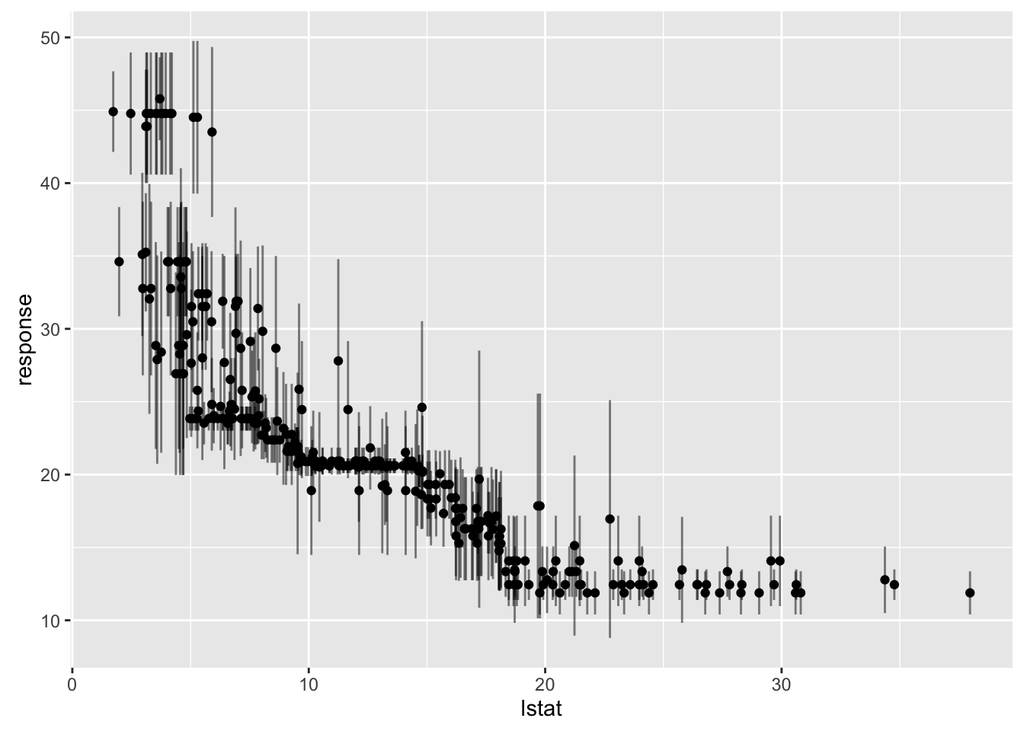

```r
data <- cbind(as.data.frame(pred), getTaskData(bh.task, subset = test.inds))
g <- ggplot(data, aes(x = lstat, y = response, ymin = response - se, ymax = response + se), col = age)
g + geom_point() + geom_linerange(alpha = 0.5)
```

### Tuning

We can set selected hyperparameters in machine learning algorithms by passing them on to `makeLearner`. By tuning the hyperparameters, we can automatically identify values that lead to the best performance. In order to do the tuning, we need to specify the *search space*, the *optimization algorithm*, and the *evaluation method* (i.e. a resampling strategy + a performance measure).

#### Grid search

1. Create the `ParamSet` object which describes the parameter space we want to search.

```r
ps <- makeParamSet(
  makeDiscreteParam("C", values = 2^(-2:2)),
  makeDiscreteParam("sigma", values = 2^(-2:2))
)
```

2. Create the `TuneControl` object which describes the optimization strategy to be used and its settings.

```r
ctrl <- makeTuneControlGrid()
```

3. Create the resampling description.

```r
rdesc <- makeResampleDesc("CV", iters = 3L)
```

4. Tuning the parameters with `tuneParams`.

```r
result <- tuneParams("classif.ksvm", task = iris.task, resampling = rdesc, par.set = ps, control = ctrl)
```

```
## [Tune] Started tuning learner classif.ksvm for parameter set:
```

```
##           Type len Def         Constr Req Tunable Trafo
## C     discrete   -   - 0.25,0.5,1,2,4   -    TRUE     -
## sigma discrete   -   - 0.25,0.5,1,2,4   -    TRUE     -
```

```
## With control class: TuneControlGrid
```

```
## Imputation value: 1
```

```
## [Tune-x] 1: C=0.25; sigma=0.25
```

```
## [Tune-y] 1: mmce.test.mean=0.0467; time: 0.0 min; memory: 159Mb use, 546Mb max
```

```
## [Tune-x] 2: C=0.5; sigma=0.25
```

```
## [Tune-y] 2: mmce.test.mean=0.0467; time: 0.0 min; memory: 159Mb use, 546Mb max
```

```
## [Tune-x] 3: C=1; sigma=0.25
```

```
## [Tune-y] 3: mmce.test.mean=0.0333; time: 0.0 min; memory: 159Mb use, 546Mb max
```

```
## [Tune-x] 4: C=2; sigma=0.25
```

```
## [Tune-y] 4: mmce.test.mean=0.04; time: 0.0 min; memory: 159Mb use, 546Mb max
```

```
## [Tune-x] 5: C=4; sigma=0.25
```

```
## [Tune-y] 5: mmce.test.mean=0.0467; time: 0.0 min; memory: 159Mb use, 546Mb max
```

```
## [Tune-x] 6: C=0.25; sigma=0.5
```

```
## [Tune-y] 6: mmce.test.mean=0.0533; time: 0.0 min; memory: 159Mb use, 546Mb max
```

```
## [Tune-x] 7: C=0.5; sigma=0.5
```

```
## [Tune-y] 7: mmce.test.mean=0.04; time: 0.0 min; memory: 159Mb use, 546Mb max
```

```
## [Tune-x] 8: C=1; sigma=0.5
```

```
## [Tune-y] 8: mmce.test.mean=0.04; time: 0.0 min; memory: 159Mb use, 546Mb max
```

```
## [Tune-x] 9: C=2; sigma=0.5
```

```
## [Tune-y] 9: mmce.test.mean=0.0467; time: 0.0 min; memory: 159Mb use, 546Mb max
```

```
## [Tune-x] 10: C=4; sigma=0.5
```

```
## [Tune-y] 10: mmce.test.mean=0.0533; time: 0.0 min; memory: 159Mb use, 546Mb max
```

```
## [Tune-x] 11: C=0.25; sigma=1
```

```
## [Tune-y] 11: mmce.test.mean=0.06; time: 0.0 min; memory: 159Mb use, 546Mb max
```

```
## [Tune-x] 12: C=0.5; sigma=1
```

```
## [Tune-y] 12: mmce.test.mean=0.0467; time: 0.0 min; memory: 159Mb use, 546Mb max
```

```
## [Tune-x] 13: C=1; sigma=1
```

```
## [Tune-y] 13: mmce.test.mean=0.0533; time: 0.0 min; memory: 159Mb use, 546Mb max
```

```
## [Tune-x] 14: C=2; sigma=1
```

```
## [Tune-y] 14: mmce.test.mean=0.0533; time: 0.0 min; memory: 159Mb use, 546Mb max
```

```
## [Tune-x] 15: C=4; sigma=1
```

```
## [Tune-y] 15: mmce.test.mean=0.06; time: 0.0 min; memory: 159Mb use, 546Mb max
```

```
## [Tune-x] 16: C=0.25; sigma=2
```

```
## [Tune-y] 16: mmce.test.mean=0.08; time: 0.0 min; memory: 159Mb use, 546Mb max
```

```
## [Tune-x] 17: C=0.5; sigma=2
```

```
## [Tune-y] 17: mmce.test.mean=0.0667; time: 0.0 min; memory: 159Mb use, 546Mb max
```

```
## [Tune-x] 18: C=1; sigma=2
```

```
## [Tune-y] 18: mmce.test.mean=0.06; time: 0.0 min; memory: 159Mb use, 546Mb max
```

```
## [Tune-x] 19: C=2; sigma=2
```

```
## [Tune-y] 19: mmce.test.mean=0.0667; time: 0.0 min; memory: 159Mb use, 546Mb max
```

```
## [Tune-x] 20: C=4; sigma=2
```

```
## [Tune-y] 20: mmce.test.mean=0.0667; time: 0.0 min; memory: 159Mb use, 546Mb max
```

```
## [Tune-x] 21: C=0.25; sigma=4
```

```
## [Tune-y] 21: mmce.test.mean=0.107; time: 0.0 min; memory: 159Mb use, 546Mb max
```

```
## [Tune-x] 22: C=0.5; sigma=4
```

```
## [Tune-y] 22: mmce.test.mean=0.107; time: 0.0 min; memory: 159Mb use, 546Mb max
```

```
## [Tune-x] 23: C=1; sigma=4
```

```
## [Tune-y] 23: mmce.test.mean=0.0933; time: 0.0 min; memory: 159Mb use, 546Mb max
```

```
## [Tune-x] 24: C=2; sigma=4
```

```
## [Tune-y] 24: mmce.test.mean=0.0933; time: 0.0 min; memory: 159Mb use, 546Mb max
```

```
## [Tune-x] 25: C=4; sigma=4
```

```
## [Tune-y] 25: mmce.test.mean= 0.1; time: 0.0 min; memory: 159Mb use, 546Mb max
```

```
## [Tune] Result: C=1; sigma=0.25 : mmce.test.mean=0.0333
```

```r
result
```

```
## Tune result:
## Op. pars: C=1; sigma=0.25
## mmce.test.mean=0.0333
```

The `show.info` argument can be set via `configureMlr`; the command `getMlrOptions()` shows the current settings. In the above example, `tuneParams` performs cross-validation for every element of the cross product (so in this case, we have 5 x 5 different combinations). The optimal parameters (which give the best mean performance) are selected in the end. In the example above, since no measure was selected, the default for classification was used (`mmce`). Alternatively, we can set a different measure; this is shown below.

```r
result <- tuneParams("classif.ksvm", task = iris.task, resampling = rdesc, par.set = ps, control = ctrl, measures = list(acc, setAggregation(acc, test.sd)), show.info = FALSE)
result
```

```
## Tune result:
## Op. pars: C=1; sigma=0.25
## acc.test.mean=0.947,acc.test.sd=0.0306
```

The object returned by `tuneParams` is a list which includes the best parameter settings (accessed via `$x`) and their estimated performance (accessed via `$y`). Through `$opt.path`, we can obtain the performance of all points evaluated.

```r
opt.grid <- as.data.frame(result$opt.path)
opt.grid
```

```
##       C sigma acc.test.mean acc.test.sd dob eol error.message exec.time
## 1  0.25  0.25     0.9400000  0.02000000   1  NA          <NA>     0.045
## 2   0.5  0.25     0.9400000  0.02000000   2  NA          <NA>     0.040
## 3     1  0.25     0.9466667  0.03055050   3  NA          <NA>     0.046
## 4     2  0.25     0.9466667  0.03055050   4  NA          <NA>     0.046
## 5     4  0.25     0.9400000  0.04000000   5  NA          <NA>     0.042
## 6  0.25   0.5     0.9400000  0.02000000   6  NA          <NA>     0.041
## 7   0.5   0.5     0.9400000  0.02000000   7  NA          <NA>     0.044
## 8     1   0.5     0.9466667  0.03055050   8  NA          <NA>     0.042
## 9     2   0.5     0.9400000  0.04000000   9  NA          <NA>     0.042
## 10    4   0.5     0.9466667  0.03055050  10  NA          <NA>     0.041
## 11 0.25     1     0.9266667  0.01154701  11  NA          <NA>     0.040
## 12  0.5     1     0.9200000  0.02000000  12  NA          <NA>     0.047
## 13    1     1     0.9266667  0.01154701  13  NA          <NA>     0.041
## 14    2     1     0.9133333  0.03055050  14  NA          <NA>     0.041
## 15    4     1     0.9133333  0.04163332  15  NA          <NA>     0.040
## 16 0.25     2     0.9066667  0.02309401  16  NA          <NA>     0.045
## 17  0.5     2     0.9066667  0.02309401  17  NA          <NA>     0.041
## 18    1     2     0.9000000  0.03464102  18  NA          <NA>     0.044
## 19    2     2     0.9000000  0.03464102  19  NA          <NA>     0.040
## 20    4     2     0.9000000  0.03464102  20  NA          <NA>     0.044
## 21 0.25     4     0.8333333  0.05033223  21  NA          <NA>     0.041
## 22  0.5     4     0.8533333  0.05033223  22  NA          <NA>     0.042
## 23    1     4     0.8666667  0.03055050  23  NA          <NA>     0.041
## 24    2     4     0.8666667  0.03055050  24  NA          <NA>     0.046
## 25    4     4     0.8666667  0.03055050  25  NA          <NA>     0.041
```

Further, we can visualize a selected performance measure using `geom_tile()` from `ggplot2`. In the code below, we ask for the color of the tiles to represent the achieved accuracy while the labels on the tiles represent the standard deviation for each of the settings attempted.

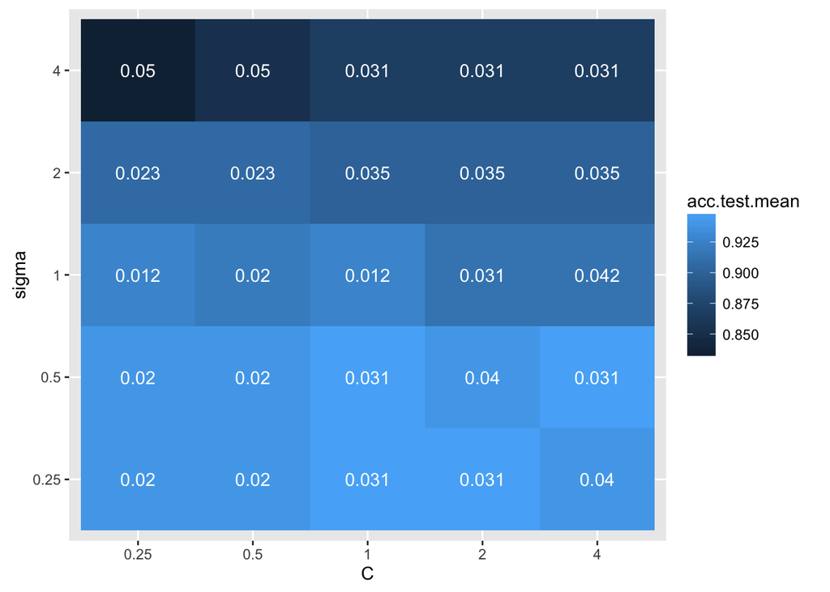

```r
g <- ggplot(opt.grid, aes(x = C, y = sigma, fill = acc.test.mean, label = round(acc.test.sd, 3)))
g + geom_tile() + geom_text(color = "white")
```

#### Using the optimal parameters

Once we have the optimal hyperameter set, we generate a learner and pass the settings as an argument in `setHyperPars`.

```r
lrn <- setHyperPars(makeLearner("classif.ksvm"), par.vals = result$x)
mod <- mlr::train(learner = lrn, task = iris.task)
predict(mod, task = iris.task)
```

```
## Prediction: 150 observations
## predict.type: response
## threshold:
## time: 0.00
##   id  truth response
## 1  1 setosa   setosa
## 2  2 setosa   setosa
## 3  3 setosa   setosa
## 4  4 setosa   setosa
## 5  5 setosa   setosa
## 6  6 setosa   setosa
```

Above, we used `mkeDiscreteParam` to discretize manually the parameters we wanted to set (here, `C` and `sigma`). We can also use their true numeric value and set `resolution = TRUE` in the control strategy to automatically discretize them. When setting the numerical parameter range, we can also pass a transformation function (`trafo`).

```r
ps <- makeParamSet(
  makeNumericParam("C", lower = 12, upper = 12, trafo = function(x) 2^x),
  makeNumericParam("sigma", lower = -12, upper = 12)
)
ctrl <- makeTuneControlGrid(resolution = 3L)
rdesc <- makeResampleDesc("CV", iters = 2L)
res <- tuneParams("classif.ksvm", task = iris.task, resampling = rdesc, par.set = ps, control = ctrl)
```

```
## [Tune] Started tuning learner classif.ksvm for parameter set:
```

```
##          Type len Def    Constr Req Tunable Trafo
## C     numeric   -   -  12 to 12   -    TRUE     Y
## sigma numeric   -   - -12 to 12   -    TRUE     -
```

```
## With control class: TuneControlGrid
```

```
## Imputation value: 1
```

```
## [Tune-x] Setting hyperpars failed: Error in setHyperPars2.Learner(learner, insert(par.vals, args)) :
##   -12 is not feasible for parameter 'sigma'!
```

```
## [Tune-x] 1: C=4.1e+03; sigma=-12
```

```
## [Tune-y] 1: mmce.test.mean=  NA; time: 0.0 min; memory: 159Mb use, 546Mb max
```

```
## [Tune-x] 2: C=4.1e+03; sigma=0
```

```
## [Tune-y] 2: mmce.test.mean=0.693; time: 0.0 min; memory: 159Mb use, 546Mb max
```

```
## [Tune-x] 3: C=4.1e+03; sigma=12
```

```
## [Tune-y] 3: mmce.test.mean=0.147; time: 0.0 min; memory: 159Mb use, 546Mb max
```

```
## [Tune] Result: C=4.1e+03; sigma=12 : mmce.test.mean=0.147
```

```r
res
```

```
## Tune result:
## Op. pars: C=4.1e+03; sigma=12
## mmce.test.mean=0.147
```

Note that calling `res$opt.path` as before returns the parameter values on the original scale before the transformation applied as set in the `trafo` option. The transformed parameters can be retrieved using `trafoOptPath`, as shown below.

```r
# original scale
as.data.frame(res$opt.path)
```

```
##    C sigma mmce.test.mean dob eol
## 1 12   -12             NA   1  NA
## 2 12     0      0.6933333   2  NA
## 3 12    12      0.1466667   3  NA
##                                                                                                        error.message
## 1 Error in setHyperPars2.Learner(learner, insert(par.vals, args)) : \n  -12 is not feasible for parameter 'sigma'!\n
## 2                                                                                                               <NA>
## 3                                                                                                               <NA>
##   exec.time
## 1        NA
## 2     0.032
## 3     0.029
```

```r
# transformed
as.data.frame(trafoOptPath(res$opt.path))
```

```
##      C sigma mmce.test.mean dob eol
## 1 4096   -12             NA   1  NA
## 2 4096     0      0.6933333   2  NA
## 3 4096    12      0.1466667   3  NA
```

The mlr package supports additional tuning algorithms to the traditional grid. In previous parts of this tutorial, we used `makeTuneControlRandom` which uses random search. An iterated F-racing algorithm is also included; the algorithm starts by considering a set of candidate parameters and completely discards any for which any statistical evidence arises against them. We show an example below with the `iris.task`. In this example, we experiment with different kernels in the svm algorithm. However, we wish to tune certain parameters with particular kernels; we can set this using the `requires` argument which states requirements on other parameters. For instance, below we make `sigma` and `degree` dependent on `rbfdot` and `polydot` kernels, respectively.

```r
ps <- makeParamSet(
  makeNumericParam("C", lower = -12, upper = 12, trafo = function(x) 2^x),
  makeDiscreteParam("kernel", values = c("vanilladot", "polydot", "rbfdot")),
  makeNumericParam("sigma", lower = -12, upper = 12, trafo = function(x) 2^x,
                   requires = quote(kernel == "rbfdot")),
  makeIntegerParam("degree", lower = 2L, upper = 5L,
                   requires = quote(kernel == "polydot"))
)
ctrl <- makeTuneControlIrace(maxExperiments = 200L)
rdesc <- makeResampleDesc("Holdout")
res <- tuneParams(learner = "classif.ksvm", task = iris.task, resampling = rdesc, par.set = ps, control = ctrl, show.info = FALSE)
head(as.data.frame(res$opt.pat))
```

```
##            C     kernel      sigma degree mmce.test.mean dob eol
## 1 11.0511248     rbfdot -11.814987     NA           0.08   1  NA
## 2  0.4836376    polydot         NA      2           0.06   2  NA
## 3  1.2211800     rbfdot   3.547916     NA           0.22   3  NA
## 4  5.2512287     rbfdot   4.942283     NA           0.40   4  NA
## 5 10.1821147 vanilladot         NA     NA           0.10   5  NA
## 6 -0.9499436 vanilladot         NA     NA           0.08   6  NA
##   error.message exec.time
## 1          <NA>     0.018
## 2          <NA>     0.017
## 3          <NA>     0.020
## 4          <NA>     0.016
## 5          <NA>     0.016
## 6          <NA>     0.017
```

```r
res
```

```
## Tune result:
## Op. pars: C=169; kernel=rbfdot; sigma=0.000427
## mmce.test.mean=0.0356
```

```r
head(as.data.frame(res$opt.path))
```

```
##            C     kernel      sigma degree mmce.test.mean dob eol
## 1 11.0511248     rbfdot -11.814987     NA           0.08   1  NA
## 2  0.4836376    polydot         NA      2           0.06   2  NA
## 3  1.2211800     rbfdot   3.547916     NA           0.22   3  NA
## 4  5.2512287     rbfdot   4.942283     NA           0.40   4  NA
## 5 10.1821147 vanilladot         NA     NA           0.10   5  NA
## 6 -0.9499436 vanilladot         NA     NA           0.08   6  NA
##   error.message exec.time
## 1          <NA>     0.018
## 2          <NA>     0.017
## 3          <NA>     0.020
## 4          <NA>     0.016
## 5          <NA>     0.016
## 6          <NA>     0.017
```

#### One step further with ModelMultiplexer

We can tune over different models at the same time and set parameters for each model using `makeModelMultiplexerParameterSet`. Once more we look at the `iris.task` classification problem set and tune SVM and randomForest algorithms at the same time.

```r
base.learners <- list(
  makeLearner("classif.ksvm"),
  makeLearner("classif.randomForest")
)
lrn <- makeModelMultiplexer(base.learners)
ps <- makeModelMultiplexerParamSet(lrn,
       makeNumericParam("sigma", lower = -12, upper = 12, trafo = function(x) 2^x),
       makeIntegerParam("ntree", lower = 1L, upper = 500L)
       )
rdesc <- makeResampleDesc("CV", iters = 2L)
ctrl <- makeTuneControlIrace(maxExperiments = 200L)
res <- tuneParams(lrn, iris.task, rdesc, par.set = ps, control = ctrl, show.info = FALSE)
res
```

```
## Tune result:
## Op. pars: selected.learner=classif.ksvm; classif.ksvm.sigma=0.403
## mmce.test.mean=0.0458
```

#### Control structures for multi-criteria tuning

It is possible that we may want to optimize multiple performance measures simultaneously when tuning parameters. The mlr package offers multi-criteria tuning algorithms as control structures which are then passed onto `tuneParamsMultiCrit`. As an example, we tune SVM hyperparameters on the `sonar.task` classification task where we aim to optimize both `fpr` and `fnr`.

```r
ps <- makeParamSet(
  makeNumericParam("C", lower = -12, upper = 12, trafo = function(x) 2^x),
  makeNumericParam("sigma", lower = -12, upper = 12, trafo = function(x) 2^x)
)

ctrl <- makeTuneMultiCritControlRandom(maxit = 30L)
rdesc <- makeResampleDesc("Holdout")
res <- tuneParamsMultiCrit("classif.ksvm", sonar.task, rdesc, measures = list(fpr, fnr), par.set = ps, control = ctrl, show.info = FALSE)
res
```

```
## Tune multicrit result:
## Points on front: 5
```

In the case of nontrivial multi-objective optimization problems, the objective functions are said to be conflicting. This could potentially result in the existence of a large number of optimal solutions. Here, as hyperparameters are tuned, the `fpr` and `fnr` measures are calculated and recorded. A *Pareto improvement* is said to occur if, the tuning of a certain parameter set, improves the lot of at least one of the measures. A solution is concerned *Pareto efficient* if no further Pareto improvements can be made. The Pareto efficient solutions make the **Pareto front**. The number of points on the front is the result shown when calling the object of the `tuneParamsMultiCrit`. Finally, the optimal solutions can be accessed using `res$x` (for the parameter sets) and `res$y` (for the estimated performance measures). All solutions cab be visualized using `plotTuneMultiCritResult` with the solutions on the Pareto front shown as bigger points (note that some - if more than one - may completely overlap).

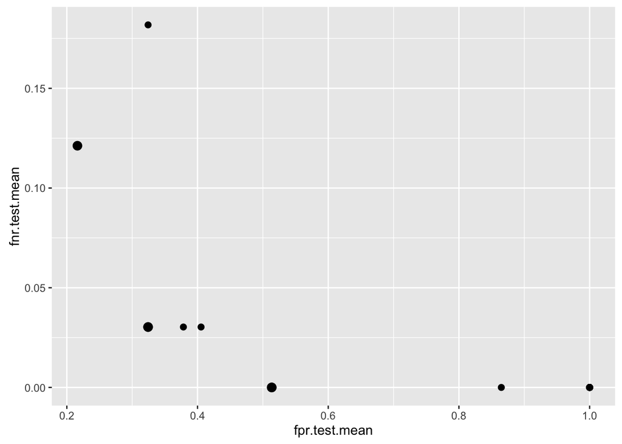

```r
plotTuneMultiCritResult(res)
```

Note that tuning works similarly in tasks other than classification and see also later section on *nested resampling* for unbiased performance estimation.

### Feature Selection

The mlr package supports two different methods for feature selection which are discussed here in this section.

#### Filter methods

Filter methods assign the features a value of **importance** which allows a ranking of the features which allows to subsequent subsetting of features to be used in a learning algorithm. A number of methods are available for calculating feature importance for classification, regression, and survival tasks (current support). The method is passed as an argument in `generateFilterValuesData`; the default is `rf.importance`.

```r
fv <- generateFilterValuesData(task = iris.task, method = "information.gain")
fv
```

```
## FilterValues:
## Task: iris-example
##           name    type information.gain
## 1 Sepal.Length numeric        0.4521286
## 2  Sepal.Width numeric        0.2672750
## 3 Petal.Length numeric        0.9402853
## 4  Petal.Width numeric        0.9554360
```

A vector of methods can also be supplied to obtain feature importance values for each specified method.

```r
fv2 <- generateFilterValuesData(task = iris.task, method = c( "information.gain", "chi.squared"))
fv2
```

```
## FilterValues:
## Task: iris-example
##           name    type information.gain chi.squared
## 1 Sepal.Length numeric        0.4521286   0.6288067
## 2  Sepal.Width numeric        0.2672750   0.4922162
## 3 Petal.Length numeric        0.9402853   0.9346311
## 4  Petal.Width numeric        0.9554360   0.9432359
```

And these can be visualized by passing the resulting object into `plotFilterValues`.

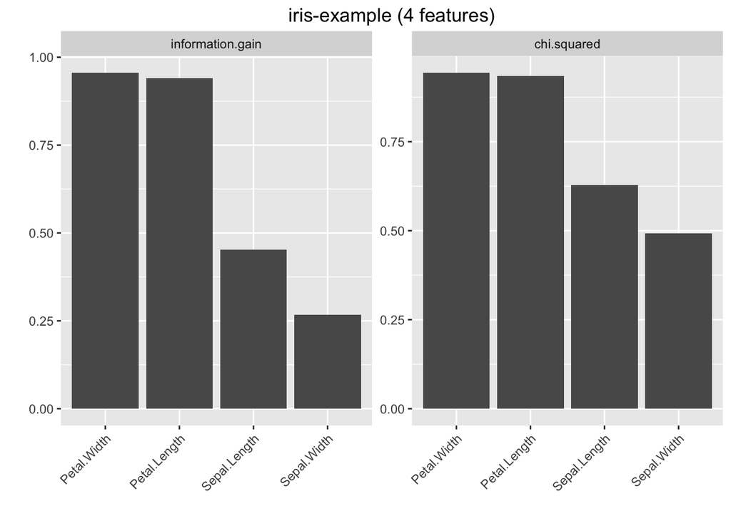

```r
plotFilterValues(fv2)
```

In this example, according to both measures, `Petal.Width` and `Petal.Length` contain the most information about the target variable `Species`.

Using this information, we can create a new task that includes a subset of the features specified by the user. To select the subset, we pass arguments to `filterFeatures`. We can choose from: `abs = K` where `K` is equal to some number of features to keep, `perc = r` where 0 < `r` < 1 is a percentage of the most important features to keep, and `threshold = m` where `m` denotes a threshold importance value (we keep features with values above `m`). In `filterFeatures`, we can either specify the method of calculating feature importance or, we can pass the object returned from `generateFilterValuesData` through the `fval` argument.

```r
filtered.task <- filterFeatures(iris.task, method = "information.gain", abs = 2)

filtered.task <- filterFeatures(iris.task, fval = fv, perc = 0.25)

filtered.task <- filterFeatures(iris.task, fval = fv, threshold = 0.5)
filtered.task
```

```
## Supervised task: iris-example
## Type: classif
## Target: Species
## Observations: 150
## Features:
## numerics  factors  ordered
##        2        0        0
## Missings: FALSE
## Has weights: FALSE
## Has blocking: FALSE
## Classes: 3
##     setosa versicolor  virginica
##         50         50         50
## Positive class: NA
```

#### Fuse a learner with a filter method

In an experiment with objectives to train a learner, we employ a resampling startegy to identify a validation method. Obviously feature selection is an important step contributing to the overall learner performance and we often want to carry out feature selection prior to each iteration identified in our resampling strategy. In what follows, we return the `iris.task` to train a fast k nearest neighbor classifier. The resampling strategy chosen is 10-fold cross-validation: in each iteration feature selection is applied via the filter method using `information.gain` as the measure and always keeping the 2 most important features.

```r
lrn <- makeFilterWrapper(learner = "classif.fnn", fw.method = "information.gain", fw.abs = 2)
rdesc <- makeResampleDesc("CV", iters = 10)
r <- resample(lrn, iris.task, rdesc, show.info = FALSE, models = TRUE)
r$aggr
```

```
## mmce.test.mean
##     0.03333333
```

By calling `models = TRUE`, we store information on the models which allows us to access information like the two selected features for each model trained. We use `getFilteredFeatures` on each of the model fitted.

```r
sfeats <- sapply(r$models, getFilteredFeatures)
table(sfeats)
```

```
## sfeats
## Petal.Length  Petal.Width
##           10           10
```

In this data set, the importance of `Petal.Length` and `Petal.Width` on `Species` seems to be very stable as they are consistently selected as the top 2 features.

#### Tuning the size of the feature subset

Just as we tuned the hyperparameters of learning algorithms in the previous section, we can also tune the size of the feature subset. We pass on a control strategy and a range of values corresponding to the number/percentage of features or threshold into `tuneParams`.

```r
lrn <- makeFilterWrapper(learner = "regr.lm", fw.method = "chi.squared")
ps <- makeParamSet(makeDiscreteParam("fw.perc", values = c(0.2, 0.5, 0.05)))
rdesc <- makeResampleDesc("CV", iters  = 3)
res <- tuneParams(lrn, bh.task, rdesc, par.set = ps, control = makeTuneControlGrid())
```

```
## [Tune] Started tuning learner regr.lm.filtered for parameter set:
```

```
##             Type len Def       Constr Req Tunable Trafo
## fw.perc discrete   -   - 0.2,0.5,0.05   -    TRUE     -
```

```
## With control class: TuneControlGrid
```

```
## Imputation value: Inf
```

```
## [Tune-x] 1: fw.perc=0.2
```

```
## [Tune-y] 1: mse.test.mean=34.6; time: 0.0 min; memory: 162Mb use, 546Mb max
```

```
## [Tune-x] 2: fw.perc=0.5
```

```
## [Tune-y] 2: mse.test.mean=28.5; time: 0.0 min; memory: 162Mb use, 546Mb max
```

```
## [Tune-x] 3: fw.perc=0.05
```

```
## [Tune-y] 3: mse.test.mean=54.6; time: 0.0 min; memory: 162Mb use, 546Mb max
```

```
## [Tune] Result: fw.perc=0.5 : mse.test.mean=28.5
```

```r
res
```

```
## Tune result:
## Op. pars: fw.perc=0.5
## mse.test.mean=28.5
```

The `$x`, `$y`, and `$opt.path` elements work as we have seen them before. We can pass the tuned parameter to generate a new wrapped learner for further use.

```r
lrn <- makeFilterWrapper("regr.lm", fw.method = "chi.squared", fw.perc = res$x$fw.perc)
mod <- mlr::train(lrn, bh.task)
mod
```

```
## Model for learner.id=regr.lm.filtered; learner.class=FilterWrapper
## Trained on: task.id = BostonHousing-example; obs = 506; features = 13
## Hyperparameters: fw.method=chi.squared,fw.perc=0.5
```

```r
getFilteredFeatures(mod)
```

```
## [1] "crim"  "zn"    "rm"    "dis"   "rad"   "lstat"
```

We show another example using the `sonar.task` classification problem and make use of the multi-criteria tuning functions we introduced in the last section.

```r
lrn <- makeFilterWrapper("classif.lda", fw.method = "chi.squared")
ps <- makeParamSet(makeNumericParam("fw.threshold", lower = 0.1, upper = 0.9))
rdesc <- makeResampleDesc("CV", iters = 10)
res <- tuneParamsMultiCrit(lrn, sonar.task, par.set = ps, resampling = rdesc, measures = list(fpr, fnr), control = makeTuneMultiCritControlRandom(maxit = 50), show.info = FALSE)
res
```

```
## Tune multicrit result:
## Points on front: 15
```

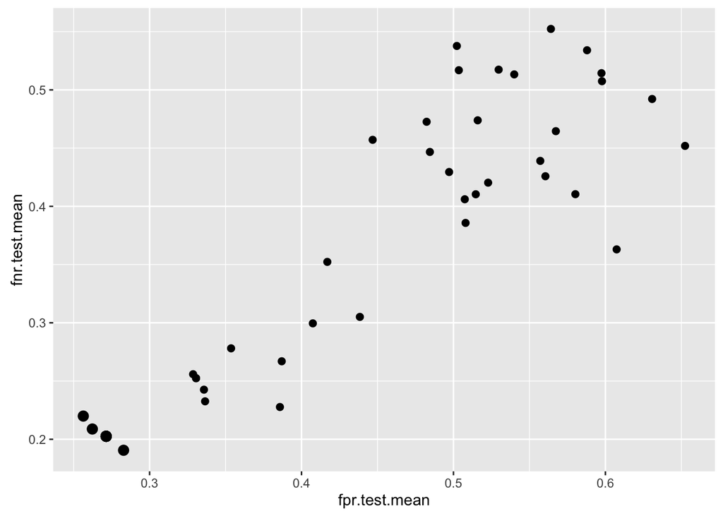

```r
plotTuneMultiCritResult(res)
```

#### Wrapper methods

In the previous subsection, feature selection was accomplished independently from the performance of a specific learning algorithm. We achieved optimal feature selection through maximizing or minimizing a criterion function. We now turn out attention to *wrapper* models where the effectiveness of the performance feature selection model is directly related to the performance of the learning algorithm, usually in terms of its predictive accuracy. Therefore, in the wrapper method, a learner is trained repeatedly on a different subset of features and the subset which leads to the learner with the best performance is chosen. To do this, we need to specify which strategy we want to use to identify the various subsets to be used. Of course we also need to choose a learning algorithm and a resampling strategy by which we aim to assess performance.

A note on the search strategy for feature selection. The mlr package offers 4 methods:

1. `FeatSelControlExhaustive` : exhaustive search; all feature sets up to a certain number of `max.features` is searched.
2. `FeatSelControlRandom`: random search; feature vectors randomly drawn up to a certain number of `max.features`.
3. `FeatSelControlSequential`: deterministic forward or backward search. Forward (backward) search starts with smaller (bigger) feature subsets and adds (removes) sequentially.
4. `FeatSelControlGA`: genetic algorithm. An adaptive search technique based on the analogy with biology in which a set of possible solutions evolves via natural selection.

In the following example, we use the *Wisconsin Prognostic Breast Cancer* data set using a random search strategy.

```r
ctrl <- makeFeatSelControlRandom(maxit = 20L)
ctrl
```

```
## FeatSel control: FeatSelControlRandom
## Same resampling instance: TRUE
## Imputation value: <worst>
## Max. features: <not used>
## Max. iterations: 20
## Tune threshold: FALSE
## Further arguments: prob=0.5
```

```r
rdesc <- makeResampleDesc("Holdout")
sfeats <- selectFeatures(learner = "surv.coxph", task = wpbc.task, resampling = rdesc, control = ctrl, show.info = FALSE)
sfeats
```

```
## FeatSel result:
## Features (16): mean_radius, mean_perimeter, mean_smoothness, mean_concavepoints, mean_fractaldim, SE_radius, SE_texture, SE_perimeter, SE_concavity, SE_symmetry, worst_texture, worst_perimeter, worst_compactness, worst_concavity, worst_fractaldim, pnodes
## cindex.test.mean=0.601
```

The selected features and corresponding performance are included in the object returned by `selectFeatures`.

```r
sfeats$x
```

```
##  [1] "mean_radius"        "mean_perimeter"     "mean_smoothness"
##  [4] "mean_concavepoints" "mean_fractaldim"    "SE_radius"
##  [7] "SE_texture"         "SE_perimeter"       "SE_concavity"
## [10] "SE_symmetry"        "worst_texture"      "worst_perimeter"
## [13] "worst_compactness"  "worst_concavity"    "worst_fractaldim"
## [16] "pnodes"
```

```r
sfeats$y
```

```
## cindex.test.mean
##         0.600639
```

We use the `bh.task` in a second example with forward sequential search. Features are added to the model until the performance improvement is smaller than some value (set by the `alpha` parameter).

```r
ctrl <- makeFeatSelControlSequential(method = "sfs", alpha = 0.02)

rdesc <- makeResampleDesc("CV", iters = 10)
sfeats <- selectFeatures(learner = "regr.lm", task = bh.task, resampling = rdesc, control = ctrl, show.info = FALSE)
sfeats
```

```
## FeatSel result:
## Features (11): crim, zn, chas, nox, rm, dis, rad, tax, ptratio, b, lstat
## mse.test.mean=23.4
```

Details of the sequential feature selection process can be retrieved using `analyzeFeatSelResult`:

```r
analyzeFeatSelResult(sfeats)
```

```
## Features         : 11
## Performance      : mse.test.mean=23.4
## crim, zn, chas, nox, rm, dis, rad, tax, ptratio, b, lstat
##
## Path to optimum:
## - Features:    0  Init   :                       Perf = 84.717  Diff: NA  *
## - Features:    1  Add    : lstat                 Perf = 38.782  Diff: 45.934  *
## - Features:    2  Add    : rm                    Perf = 31.306  Diff: 7.4758  *
## - Features:    3  Add    : ptratio               Perf = 27.929  Diff: 3.3775  *
## - Features:    4  Add    : dis                   Perf = 27.054  Diff: 0.87535  *
## - Features:    5  Add    : nox                   Perf = 25.611  Diff: 1.4427  *
## - Features:    6  Add    : b                     Perf = 25.019  Diff: 0.59183  *
## - Features:    7  Add    : chas                  Perf = 24.586  Diff: 0.43327  *
## - Features:    8  Add    : zn                    Perf = 24.354  Diff: 0.23231  *
## - Features:    9  Add    : rad                   Perf = 24.215  Diff: 0.1382  *
## - Features:   10  Add    : tax                   Perf = 23.78  Diff: 0.4353  *
## - Features:   11  Add    : crim                  Perf = 23.377  Diff: 0.40282  *
##
## Stopped, because no improving feature was found.
```

#### Fuse a learner with a wrapper method

Similarly to what we did above with fusing a learner with the filter, we can do so here with the wrapper. We fuse the feature selection and resampling strategies with a learner. The learner is trained on the selected feature subset.

```r
rdesc <- makeResampleDesc("CV", iters = 3)
lrn <- makeFeatSelWrapper(learner = "surv.coxph", resampling = rdesc, control = makeFeatSelControlRandom(maxit = 10), show.info = FALSE)
mod <- train(lrn, wpbc.task)
mod
```

```
## Model for learner.id=surv.coxph.featsel; learner.class=FeatSelWrapper
## Trained on: task.id = wpbc-example; obs = 194; features = 32
## Hyperparameters:
```

```r
sfeats <- getFeatSelResult(mod)
sfeats
```

```
## FeatSel result:
## Features (20): mean_radius, mean_texture, mean_area, mean_smoothness, mean_compactness, mean_symmetry, mean_fractaldim, SE_radius, SE_smoothness, SE_compactness, SE_concavity, SE_symmetry, worst_radius, worst_perimeter, worst_smoothness, worst_concavity, worst_concavepoints, worst_symmetry, worst…
## cindex.test.mean=0.637
```

```r
sfeats$x
```

```
##  [1] "mean_radius"         "mean_texture"        "mean_area"
##  [4] "mean_smoothness"     "mean_compactness"    "mean_symmetry"
##  [7] "mean_fractaldim"     "SE_radius"           "SE_smoothness"
## [10] "SE_compactness"      "SE_concavity"        "SE_symmetry"
## [13] "worst_radius"        "worst_perimeter"     "worst_smoothness"
## [16] "worst_concavity"     "worst_concavepoints" "worst_symmetry"
## [19] "worst_fractaldim"    "pnodes"
```

The 5-fold cross-validated performance of the learner we specified above can be computed through `resample`.

```r
out.rdesc <- makeResampleDesc("CV", iters = 5)

r <- resample(learner = lrn, task = wpbc.task, resampling = out.rdesc, models = TRUE, show.info = FALSE)

r$aggr
```

```
## cindex.test.mean
##        0.6242516
```

With `models = TRUE` in `resample`, we can access the feature selection for each model by applying `getFeatSelResult`.

```r
lapply(r$models, getFeatSelResult)
```

```
## [[1]]
## FeatSel result:
## Features (15): mean_texture, mean_area, mean_smoothness, mean_symmetry, SE_texture, SE_area, SE_compactness, SE_concavity, worst_perimeter, worst_area, worst_compactness, worst_concavity, worst_symmetry, tsize, pnodes
## cindex.test.mean=0.657
##
## [[2]]
## FeatSel result:
## Features (17): mean_texture, mean_area, mean_smoothness, mean_compactness, mean_fractaldim, SE_texture, SE_area, SE_smoothness, SE_concavity, SE_concavepoints, SE_symmetry, SE_fractaldim, worst_radius, worst_compactness, worst_concavity, worst_symmetry, pnodes
## cindex.test.mean=0.669
##
## [[3]]
## FeatSel result:
## Features (18): mean_texture, mean_smoothness, mean_concavepoints, mean_symmetry, mean_fractaldim, SE_radius, SE_perimeter, SE_area, SE_smoothness, SE_compactness, SE_concavepoints, SE_fractaldim, worst_radius, worst_area, worst_smoothness, worst_concavity, worst_fractaldim, pnodes
## cindex.test.mean=0.683
##
## [[4]]
## FeatSel result:
## Features (19): mean_radius, mean_perimeter, mean_smoothness, mean_compactness, mean_concavepoints, mean_symmetry, mean_fractaldim, SE_radius, SE_texture, SE_perimeter, SE_area, SE_compactness, SE_concavity, SE_fractaldim, worst_perimeter, worst_compactness, worst_concavity, worst_symmetry, worst_…
## cindex.test.mean=0.656
##
## [[5]]
## FeatSel result:
## Features (13): mean_radius, mean_perimeter, mean_area, mean_fractaldim, SE_radius, SE_perimeter, SE_smoothness, SE_symmetry, worst_radius, worst_perimeter, worst_smoothness, worst_symmetry, worst_fractaldim
## cindex.test.mean=0.735
```

### Nested Resampling

When we introduced *tuning*, we carry out the optimization over the same data. As a result, the estimated performance could be optimistically biased. To obtain an unbiased performance estimatation, we use **nested resampling**. In nested resampling, data preprocessing and feature selection is included in each training/test data resulting in an honest performance estimate. As an example consider a case where we want to train a learner with hyperparameter tuning. Suppose we choose 3-fold cross-validation as our resampling strategy; this creates three pairs of training/test sets which consist of the *outer resampling loop*. For *each* pair, we perform tuning with a new resampling strategy (say, 4-fold cross-validation), use the tuned parameters on the training set of that pair to fit a model and evaluate the model’s performance on the test set. This gives one set of hyperparameters for each of the 3 pairs in the outer resampling.

The mlr package offers a way to do this nested resampling without actually programming any loops:

1. Generate a wrapped learner using `makeTuneWrapper` or `makeFeatSelWrapper` and specify the **inner** resampling strategy using the `resampling` argument.
2. Call function `resample` and pass the **outer** resampling startegy to its `resampling` argument.

Different inner and outer resampling strategies can be used. It is common to have the prediction and performance evaluation on a fixed outer set hence the outer strategy can be set using `makeFixedHoldoutInstance` to generate the outer resampling. For the inner resampling strategy, using `ResampleDesc` is preferable to `ResampleInstance`. The default setting is for the inner resampling strategy to be instantiated just once so tuning/feature selection are compared to the same inner training/test sets. However, if needed, this can be turned off by setting `same.resampling.instance = FALSE` in the `make` tuning/feature selection functions.

Parallelizing nested resampling is usually a good idea as it can be computationally expensive. However, for the purposes of this tutorial and to keep things fast, we keep the iterations in the loops, low.

#### Tuning

We carry out nested resampling with tuning first. The objective is to train a learner using the `ksvm` learner class on a classification task (yes, the `iris` data of course!) and tune the hyperparameters `C` and `sigma`. To set this up, we need a search space and a search strategy, as before (see earlier section on *tuning*).

```r
ps <- makeParamSet(
  makeDiscreteParam("C", values = 2^(-2:2)),
  makeDiscreteParam("sigma", values = 2^(-2:2))
)
ctrl <- makeTuneControlGrid() #using defaults
```

We choose *subsampling* as the inner strategy with 2 iterations (and the default split date of 2/3). In subsampling, the size of the training and test sets is independent of the number of folds (vs *k*-fold CV) but since the split is random, some obervations may never be selected and others may be selected many times. Further, the resampling here is done without replacement so each subsample of size *b* is a sample from the true, unknown distribution of the original sample. This is in contrast with bootstrap resampling where each sample (this is with replacement) has the same size as the original sample but is now from the empirical distribution associated with the original sample.

```r
inner <- makeResampleDesc("Subsample", iters = 2)
lrn <- makeTuneWrapper("classif.ksvm", resampling = inner, par.set = ps, control = ctrl, show.info = FALSE)
```

For the outer resampling loop, we choose 3-fold cross-validation.

```r
outer <- makeResampleDesc("CV", iters = 3)
r <- resample(lrn, iris.task, resampling = outer, extract = getTuneResult, show.info = FALSE)
r
```

```
## Resample Result
## Task: iris-example
## Learner: classif.ksvm.tuned
## mmce.aggr: 0.06
## mmce.mean: 0.06
## mmce.sd: 0.04
## Runtime: 18.0173
```

```r
#error rates on outer tests
r$measures.test
```

```
##   iter mmce
## 1    1 0.10
## 2    2 0.06
## 3    3 0.02
```

Recall that if we want access to the train error rates as well, we need to set `predict = "both"` in the *outer* resampling strategy.

In `resample` we can use the function `extract` to extract infromation from a fitted model during resampling. Keeping the entire model may be too expensive but this can be set using `models = TRUE`. The function `getTuneResult` allows us to access the optimal set of hyperparameters in each iteration in the `outer` loop. When calling `r$extract` we obtain the optimal hyperparameter values as well as the aggregated performance value from the *inner* iterations (here, we asked for 2 iters). This is in contrast with `r$measures.test`.

```r
r$extract
```

```
## [[1]]
## Tune result:
## Op. pars: C=2; sigma=0.25
## mmce.test.mean=0.0147
##
## [[2]]
## Tune result:
## Op. pars: C=4; sigma=0.25
## mmce.test.mean=   0
##
## [[3]]
## Tune result:
## Op. pars: C=2; sigma=0.25
## mmce.test.mean=0.0147
```

It is possible to compare the performance measures for each pair of settings for `C` and `sigma` tried in each iteration in the outer resampling.

```r
opt.paths <- getNestedTuneResultsOptPathDf(r) #returns df
head(opt.paths, 10)
```

```
##       C sigma mmce.test.mean dob eol error.message exec.time iter
## 1  0.25  0.25     0.08823529   1  NA          <NA>     0.032    1
## 2   0.5  0.25     0.04411765   2  NA          <NA>     0.031    1
## 3     1  0.25     0.01470588   3  NA          <NA>     0.033    1
## 4     2  0.25     0.01470588   4  NA          <NA>     0.033    1
## 5     4  0.25     0.01470588   5  NA          <NA>     0.030    1
## 6  0.25   0.5     0.07352941   6  NA          <NA>     0.029    1
## 7   0.5   0.5     0.02941176   7  NA          <NA>     0.027    1
## 8     1   0.5     0.01470588   8  NA          <NA>     0.028    1
## 9     2   0.5     0.01470588   9  NA          <NA>     0.033    1
## 10    4   0.5     0.04411765  10  NA          <NA>     0.032    1
```

The optimal configuration depends on the data but from this experiment, one can identify a good range of hyperparameters that give good performance. Instead of going through the results in a table one by one, it is easier to visualize the results using a tile plot representing the search grid colored by the `mmce.test.mean`.

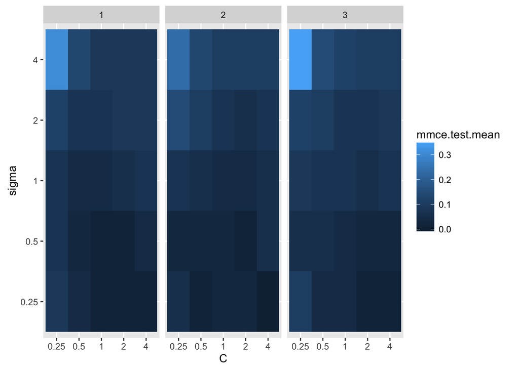

```r
g <- ggplot(opt.paths, aes(x = C, y = sigma, fill = mmce.test.mean)) + geom_tile() + facet_wrap( ~ iter)
g
```

Lastly, if we want to access just the optimal hyperparameter values for each iteration, we can use the `resample` object with `getNestedTuneResultsX`.

```r
getNestedTuneResultsX(r)
```

```
##   C sigma
## 1 2  0.25
## 2 4  0.25
## 3 2  0.25
```

#### Feature selection

Nested resampling with feature selection wrapper works very similary to the tuning example in the previous subsection. We create a learner with the feature selection wrapper and pass an inner resampling strategy. For each iteration in the resampling strategy made up of training/test sets, feature selection according to the strategy chosen is carried out. Then, each training in the outer resampling is trained with its selected features and the performance is evaluated on the correspoding test set.

```r
inner <- makeResampleDesc("CV", iters = 3)
lrn <- makeFeatSelWrapper("regr.lm", resampling = inner, control = makeFeatSelControlSequential(method = "sfs"), show.info = FALSE)

outer <- makeResampleDesc("Subsample", iters = 2)
r <- resample(lrn, bh.task, resampling = outer, extract = getFeatSelResult, show.info = FALSE)
r
```

```
## Resample Result
## Task: BostonHousing-example
## Learner: regr.lm.featsel
## mse.aggr: 24.23
## mse.mean: 24.23
## mse.sd: 9.40
## Runtime: 37.7665
```

```r
r$measures.test
```

```
##   iter      mse
## 1    1 30.88093
## 2    2 17.58244
```

Again, we can access the information we asked to be extracted using `r$extract`. We then access the features selected in the two iterations in the outer resampling.

```r
r$extract
```

```
## [[1]]
## FeatSel result:
## Features (8): crim, zn, chas, nox, rm, dis, ptratio, lstat
## mse.test.mean=21.4
##
## [[2]]
## FeatSel result:
## Features (8): nox, rm, dis, rad, tax, ptratio, b, lstat
## mse.test.mean=28.9
```

```r
r$extract[[1]]$x
```

```
## [1] "crim"    "zn"      "chas"    "nox"     "rm"      "dis"     "ptratio"
## [8] "lstat"
```

```r
r$extract[[1]]$y
```

```
## mse.test.mean
##      21.38866
```

The optimization path for each iteration in the outer loop can be read using the function `analyzeFeatSelResult` which can be applied to `r$extract` in a loop.

```r
opt.paths <- lapply(r$extract, function(x) analyzeFeatSelResult(x))
```

```
## Features         : 8
## Performance      : mse.test.mean=21.4
## crim, zn, chas, nox, rm, dis, ptratio, lstat
##
## Path to optimum:
## - Features:    0  Init   :                       Perf = 86.248  Diff: NA  *
## - Features:    1  Add    : lstat                 Perf = 38.645  Diff: 47.603  *
## - Features:    2  Add    : rm                    Perf = 28.621  Diff: 10.024  *
## - Features:    3  Add    : ptratio               Perf = 25.204  Diff: 3.4167  *
## - Features:    4  Add    : chas                  Perf = 24.014  Diff: 1.1898  *
## - Features:    5  Add    : dis                   Perf = 23.653  Diff: 0.36175  *
## - Features:    6  Add    : nox                   Perf = 22.045  Diff: 1.6073  *
## - Features:    7  Add    : zn                    Perf = 21.726  Diff: 0.31956  *
## - Features:    8  Add    : crim                  Perf = 21.389  Diff: 0.33704  *
##
## Stopped, because no improving feature was found.
## Features         : 8
## Performance      : mse.test.mean=28.9
## nox, rm, dis, rad, tax, ptratio, b, lstat
##
## Path to optimum:
## - Features:    0  Init   :                       Perf = 92.688  Diff: NA  *
## - Features:    1  Add    : lstat                 Perf = 43.42  Diff: 49.268  *
## - Features:    2  Add    : rm                    Perf = 36.497  Diff: 6.9235  *
## - Features:    3  Add    : ptratio               Perf = 33.083  Diff: 3.4137  *
## - Features:    4  Add    : dis                   Perf = 31.765  Diff: 1.318  *
## - Features:    5  Add    : nox                   Perf = 29.979  Diff: 1.7865  *
## - Features:    6  Add    : b                     Perf = 29.438  Diff: 0.54038  *
## - Features:    7  Add    : rad                   Perf = 29.206  Diff: 0.23183  *
## - Features:    8  Add    : tax                   Perf = 28.941  Diff: 0.265  *
##
## Stopped, because no improving feature was found.
```

```r
opt.paths
```

#### Filter methods with tuning

As seen previously, filter methods assign an importance value to each feature; upon setting a threshold value or a fixed number/percentage ranking the most important features, a subset of variables may be selected for training a learner. The threshold or fixed number/percentage of features to keep usually needs to be tuned. To do this, we need to make a `Filter` wrapper where we choose a filtering method - we tune the parameter associated with the subset selection in a `Tune` wrapper. So we wrap a base learner (here, we fuse linear regression on the `bh.task`) twice.

```r
lrn <- makeFilterWrapper(learner = "regr.lm", fw.method = "chi.squared")
ps <- makeParamSet(
  makeDiscreteParam("fw.threshold", values = seq(0, 1, 0.2))
)
ctrl <- makeTuneControlGrid()
inner <- makeResampleDesc("CV", iters = 3)
lrn <- makeTuneWrapper(learner  = lrn, resampling = inner, par.set = ps,
                       control = ctrl, show.info = FALSE)
```

The subset selection parameter is tuned in the inner resampling loop using data from each iteration in the outer resampling. The chosen parameter is used to train a learner using each of the training set in the outer resampling. The outer resampling strategy here is chosen as 3-fold cross-validation.

```r
outer <- makeResampleDesc("CV", iters = 3)
r <- resample(learner = lrn, task = bh.task, resampling = outer, models = TRUE, show.info = FALSE)
r
```

```
## Resample Result
## Task: BostonHousing-example
## Learner: regr.lm.filtered.tuned
## mse.aggr: 25.58
## mse.mean: 25.58
## mse.sd: 2.50
## Runtime: 6.72188
```

The regression task `bh.task` has 506 observations and 13 features. In the example above we kept the models in `resample` and so we can access information about them contained in the object returned by `resample`.

```r
r$models
```

```
## [[1]]
## Model for learner.id=regr.lm.filtered.tuned; learner.class=TuneWrapper
## Trained on: task.id = BostonHousing-example; obs = 337; features = 13
## Hyperparameters: fw.method=chi.squared
##
## [[2]]
## Model for learner.id=regr.lm.filtered.tuned; learner.class=TuneWrapper
## Trained on: task.id = BostonHousing-example; obs = 337; features = 13
## Hyperparameters: fw.method=chi.squared
##
## [[3]]
## Model for learner.id=regr.lm.filtered.tuned; learner.class=TuneWrapper
## Trained on: task.id = BostonHousing-example; obs = 338; features = 13
## Hyperparameters: fw.method=chi.squared
```

Note that `r$models` gives us information on the number of observations used to train the learner and what hyperparameters were explored. The number of features indicated is the number included in the task, it does not represent the size of the subset of features selected. Feature selection information can be extracted using the function `getFilteredFeatures`.

```r
lapply(r$models, getFilteredFeatures) #all features?
```

```
## [[1]]
##  [1] "crim"    "zn"      "indus"   "chas"    "nox"     "rm"      "age"
##  [8] "dis"     "rad"     "tax"     "ptratio" "b"       "lstat"
##
## [[2]]
##  [1] "crim"    "zn"      "indus"   "chas"    "nox"     "rm"      "age"
##  [8] "dis"     "rad"     "tax"     "ptratio" "b"       "lstat"
##
## [[3]]
##  [1] "crim"    "zn"      "indus"   "chas"    "nox"     "rm"      "age"
##  [8] "dis"     "rad"     "tax"     "ptratio" "b"       "lstat"
```

```r
lapply(r$models, function(x) getFilteredFeatures(x$learner.model$next.model))
```

```
## [[1]]
##  [1] "crim"    "zn"      "indus"   "nox"     "rm"      "age"     "dis"
##  [8] "rad"     "tax"     "ptratio" "b"       "lstat"
##
## [[2]]
##  [1] "crim"    "zn"      "indus"   "chas"    "nox"     "rm"      "age"
##  [8] "dis"     "rad"     "tax"     "ptratio" "b"       "lstat"
##
## [[3]]
##  [1] "crim"    "zn"      "indus"   "nox"     "rm"      "age"     "dis"
##  [8] "rad"     "tax"     "ptratio" "b"       "lstat"
```

[Ok, so calling `getFilteredFeatures` on `r$models` returns all available features, I suppose that has to do something with the double wrapper but couldn’t find info on `next.model` anywhere. When we just used the `FilterWrapper` learner in the previous section, `getFilteredFeatures(r$models)` returned the *selected* features. Since we often do not want to keep the models since it can get expensive, we can use `extract = function(x) getFilteredFeatures(x$learner.model$next.model)` in `resample` to get the filtered features in this case].

We can access the tune results from the full model using the function `getTuneResult`. Of course note that if the models are not kept, then we can still access information on the tuning and, from that, information on the optimization path by setting `extract = getTuneResult` in `resample`.

```r
res <- lapply(r$models, getTuneResult)
res
```

```
## [[1]]
## Tune result:
## Op. pars: fw.threshold=0.4
## mse.test.mean=25.1
##
## [[2]]
## Tune result:
## Op. pars: fw.threshold=0
## mse.test.mean=23.2
##
## [[3]]
## Tune result:
## Op. pars: fw.threshold=0.4
## mse.test.mean=24.7
```

From `res`, we can then obtain information on the optimization paths.

```r
opt.paths <- lapply(res, function(x) as.data.frame(x$opt.path))
opt.paths
```

```
## [[1]]
##   fw.threshold mse.test.mean dob eol error.message exec.time
## 1            0      25.15489   1  NA          <NA>     0.150
## 2          0.2      25.14266   2  NA          <NA>     0.177
## 3          0.4      25.07685   3  NA          <NA>     0.154
## 4          0.6      36.15393   4  NA          <NA>     0.152
## 5          0.8      88.66949   5  NA          <NA>     0.139
## 6            1      88.66949   6  NA          <NA>     0.140
##
## [[2]]
##   fw.threshold mse.test.mean dob eol error.message exec.time
## 1            0      23.20063   1  NA          <NA>     0.156
## 2          0.2      23.92397   2  NA          <NA>     0.148
## 3          0.4      23.42240   3  NA          <NA>     0.145
## 4          0.6      28.11603   4  NA          <NA>     0.158
## 5          0.8      87.40533   5  NA          <NA>     0.148
## 6            1      87.40533   6  NA          <NA>     0.163
##
## [[3]]
##   fw.threshold mse.test.mean dob eol error.message exec.time
## 1            0      24.72981   1  NA          <NA>     0.156
## 2          0.2      24.86387   2  NA          <NA>     0.175
## 3          0.4      24.70259   3  NA          <NA>     0.148
## 4          0.6      28.57466   4  NA          <NA>     0.157
## 5          0.8      79.65968   5  NA          <NA>     0.146
## 6            1      79.65968   6  NA          <NA>     0.148
```

#### Benchmark experiments

We now extend the techniques used in nested resampling above to benchmark experiments where we compare different learners on one or more tasks. Tuning or feature selection occurs using different inner resampling descriptions and then benchmark is called with outer resampling for all tasks.

**Example 1: Two tasks, two learners, tuning**

```r
tasks <- list(iris.task, sonar.task)

# svm tune wrapper in inner resampling loop
ps <- makeParamSet(
  makeDiscreteParam("C", 2^(-1:1)),
  makeDiscreteParam("sigma", 2^(-1:1))
)
ctrl <- makeTuneControlGrid()
inner <- makeResampleDesc("Holdout")
lrn1 <- makeTuneWrapper("classif.ksvm", resampling = inner, par.set = ps, control = ctrl, show.info = FALSE)

# knn tune wrapper in inner resampling loop
ps <- makeParamSet(makeDiscreteParam("k", 3:5))
ctrl <- makeTuneControlGrid()
inner <- makeResampleDesc("Subsample", iters = 3)
lrn2 <- makeTuneWrapper("classif.knn", resampling = inner, control = ctrl, par.set = ps, show.info = FALSE )

lrns <- list(lrn1, lrn2)

# outer resampling loop
outer <- list(makeResampleDesc("Holdout"), makeResampleDesc("Bootstrap", iters = 2))
res <- benchmark(lrns, tasks, outer, measures = list(acc, ber), show.info = FALSE)
# aggregated performances from the outer resampling loop
res
```

```
##         task.id         learner.id acc.test.mean ber.test.mean
## 1  iris-example classif.ksvm.tuned     1.0000000    0.00000000
## 2  iris-example  classif.knn.tuned     0.9800000    0.02083333
## 3 Sonar-example classif.ksvm.tuned     0.5650000    0.48026316
## 4 Sonar-example  classif.knn.tuned     0.7535714    0.26017231
```

The `resamplings` argument in `benchmark` gives resampling strategies for *each* task. If only one is applied, it is replicated to match the number of tasks, if none are applied, the default 10-fold corss-validation is used. So, in the above example, the outer resampling for the `iris` task is set to *holdout* and for the `sonar` task is set to *bootstrap* with 2 iterations.

We can access the benchmark result using the `get` functions available in the mlr package. We can access the outer resampling individual performances using `getBMRPerformances`.

```r
getBMRPerformances(res, as.df = TRUE)
```

```
##         task.id         learner.id iter       acc        ber
## 1  iris-example classif.ksvm.tuned    1 1.0000000 0.00000000
## 2  iris-example  classif.knn.tuned    1 0.9800000 0.02083333
## 3 Sonar-example classif.ksvm.tuned    1 0.5833333 0.46052632
## 4 Sonar-example classif.ksvm.tuned    2 0.5466667 0.50000000
## 5 Sonar-example  classif.knn.tuned    1 0.7738095 0.23627002
## 6 Sonar-example  classif.knn.tuned    2 0.7333333 0.28407461
```

This gives the result of each iteration specified in the outer resampling strategy for each task, trained on each learner. Since for the `iris` task we use *holdout*, the performance is tested on a single test set for each learner. With the `sonar` task, we have *bootstrap* with 2 iterations, we get 2 test sets for each learner.

To obtain the results of the tuning, we use `getBMRTuneResults` on the object returned by `benchmark`.

```r
getBMRTuneResults(res, as.df = TRUE)
```

```
##         task.id         learner.id iter  C sigma mmce.test.mean  k
## 1  iris-example classif.ksvm.tuned    1  1   0.5     0.08823529 NA
## 2  iris-example  classif.knn.tuned    1 NA    NA     0.04901961  5
## 3 Sonar-example classif.ksvm.tuned    1  2   0.5     0.20000000 NA
## 4 Sonar-example classif.ksvm.tuned    2  1   2.0     0.25714286 NA
## 5 Sonar-example  classif.knn.tuned    1 NA    NA     0.18571429  3
## 6 Sonar-example  classif.knn.tuned    2 NA    NA     0.22857143  3
```

The `task.ids` and `learner.ids` arguments can be used in `getBMRTuneResults` to access the tuning results from individual learners and tasks. We can access the tuned hyperparameter settings from a nested tuning using `getNestedTuneResultsX`; this takes as an argument a `ResampleResult` so in the case of the `benchmark` object, we need to input the element from the list of results contained in the benchmark object `res$results`.

```r
# tuned hyperparameters
getNestedTuneResultsX(res$results[["Sonar-example"]][["classif.ksvm.tuned"]])
```

```
##   C sigma
## 1 2   0.5
## 2 1   2.0
```

```r
# get the opt.paths from each tuning step from the outer resampling
getNestedTuneResultsOptPathDf(res$results[["Sonar-example"]][["classif.ksvm.tuned"]])
```

```
##      C sigma mmce.test.mean dob eol error.message exec.time iter
## 1  0.5   0.5      0.2428571   1  NA          <NA>     0.027    1
## 2    1   0.5      0.2142857   2  NA          <NA>     0.034    1
## 3    2   0.5      0.2000000   3  NA          <NA>     0.027    1
## 4  0.5     1      0.2428571   4  NA          <NA>     0.032    1
## 5    1     1      0.2428571   5  NA          <NA>     0.032    1
## 6    2     1      0.2428571   6  NA          <NA>     0.034    1
## 7  0.5     2      0.2428571   7  NA          <NA>     0.033    1
## 8    1     2      0.2428571   8  NA          <NA>     0.031    1
## 9    2     2      0.2428571   9  NA          <NA>     0.034    1
## 10 0.5   0.5      0.4428571   1  NA          <NA>     0.033    2
## 11   1   0.5      0.2571429   2  NA          <NA>     0.030    2
## 12   2   0.5      0.2571429   3  NA          <NA>     0.032    2
## 13 0.5     1      0.4428571   4  NA          <NA>     0.029    2
## 14   1     1      0.2571429   5  NA          <NA>     0.027    2
## 15   2     1      0.2571429   6  NA          <NA>     0.029    2
## 16 0.5     2      0.4428571   7  NA          <NA>     0.033    2
## 17   1     2      0.2571429   8  NA          <NA>     0.032    2
## 18   2     2      0.2571429   9  NA          <NA>     0.032    2
```

**Example 2: One task, two learners, feature selection**

In this example, we wrap a linear regression learner with feature selection wrapper achieved by a sequential forward search. The features are selected using a two-iteration, subsample strategy (inner resampling). The second learner is a base `rpart` regression algorithm (no feature selection).

```r
ctrl <- makeFeatSelControlSequential(method = "sfs")
inner <- makeResampleDesc("Subsample", iters = 2)
lrn <- makeFeatSelWrapper("regr.lm", resampling = inner, control = ctrl, show.info = FALSE)

lrns <- list(makeLearner("regr.rpart"), lrn)

outer <- makeResampleDesc("Subsample", iters = 2)
res <- benchmark(learners = lrns, tasks = bh.task, resamplings = outer, show.info = FALSE)
res
```

```
##                 task.id      learner.id mse.test.mean
## 1 BostonHousing-example      regr.rpart      19.91970
## 2 BostonHousing-example regr.lm.featsel      30.56572
```

The selected features can be accessed using `getBMRFeatSelResults`:

```r
getBMRFeatSelResults(res)
```

```
## $`BostonHousing-example`
## $`BostonHousing-example`$regr.rpart
## NULL
##
## $`BostonHousing-example`$regr.lm.featsel
## $`BostonHousing-example`$regr.lm.featsel[[1]]
## FeatSel result:
## Features (9): crim, nox, rm, dis, rad, tax, ptratio, b, lstat
## mse.test.mean=22.2
##
## $`BostonHousing-example`$regr.lm.featsel[[2]]
## FeatSel result:
## Features (4): crim, rm, ptratio, lstat
## mse.test.mean=19.5
```

Again, we can access specific learners:

```r
feats <- getBMRFeatSelResults(res, learner.ids = "regr.lm.featsel")
feats <- feats[["BostonHousing-example"]][["regr.lm.featsel"]]
```

The list `feats` now has information on the outer resampling iterations where for each element in the list, `$x` and `$y` access the features and resampled performance of the test set.

```r
feats[[1]]$x
```

```
## [1] "crim"    "nox"     "rm"      "dis"     "rad"     "tax"     "ptratio"
## [8] "b"       "lstat"
```

```r
feats[[1]]$y
```

```
## mse.test.mean
##      22.23291
```

The optimization paths indicating which features were selected during the feature selection search along with the corresponding test performances can be extracted using `$opt.path`.

```r
opt.paths <- lapply(feats, function(x) as.data.frame(x$opt.path))
head(opt.paths[[1]])
```

```
##   crim zn indus chas nox rm age dis rad tax ptratio b lstat mse.test.mean
## 1    0  0     0    0   0  0   0   0   0   0       0 0     0      86.40099
## 2    1  0     0    0   0  0   0   0   0   0       0 0     0      71.58366
## 3    0  1     0    0   0  0   0   0   0   0       0 0     0      74.62474
## 4    0  0     1    0   0  0   0   0   0   0       0 0     0      66.05012
## 5    0  0     0    1   0  0   0   0   0   0       0 0     0      85.55271
## 6    0  0     0    0   1  0   0   0   0   0       0 0     0      73.41056
##   dob eol error.message exec.time
## 1   1   2          <NA>     0.010
## 2   2   2          <NA>     0.015
## 3   2   2          <NA>     0.015
## 4   2   2          <NA>     0.015
## 5   2   2          <NA>     0.020
## 6   2   2          <NA>     0.016
```

The function `analyzeFeatSelResult` gives a clearer overview of what feature has been added in sequence with the improvement in performance.

```r
analyzeFeatSelResult(feats[[1]])
```

```
## Features         : 9
## Performance      : mse.test.mean=22.2
## crim, nox, rm, dis, rad, tax, ptratio, b, lstat
##
## Path to optimum:
## - Features:    0  Init   :                       Perf = 86.401  Diff: NA  *
## - Features:    1  Add    : lstat                 Perf = 40.011  Diff: 46.39  *
## - Features:    2  Add    : ptratio               Perf = 31.236  Diff: 8.7748  *
## - Features:    3  Add    : rm                    Perf = 25.631  Diff: 5.6047  *
## - Features:    4  Add    : b                     Perf = 24.864  Diff: 0.7676  *
## - Features:    5  Add    : dis                   Perf = 24.429  Diff: 0.43506  *
## - Features:    6  Add    : nox                   Perf = 22.707  Diff: 1.7219  *
## - Features:    7  Add    : crim                  Perf = 22.471  Diff: 0.23618  *
## - Features:    8  Add    : rad                   Perf = 22.377  Diff: 0.094093  *
## - Features:    9  Add    : tax                   Perf = 22.233  Diff: 0.14379  *
##
## Stopped, because no improving feature was found.
```

**Example 3: One task, two learners, feature filtering with tuning**

This is an example where we use feature filtering and tune a parameter in the filtering method.

```r
# feature filtering with tuning in inner loop
lrn <- makeFilterWrapper(learner = "regr.lm", fw.method = "chi.squared")
ps <- makeParamSet(makeDiscreteParam("fw.abs", values = seq_len(getTaskNFeats(bh.task))) )
ctrl <- makeTuneControlGrid()
inner <- makeResampleDesc("CV", iters = 2)
lrn <- makeTuneWrapper(lrn, resampling = inner, par.set = ps, control = ctrl, show.info = FALSE)

# outer loop
lrns <- list(makeLearner("regr.rpart"), lrn)
outer <- makeResampleDesc("Subsample", iters = 3)
res <- benchmark(lrns, tasks = bh.task, resamplings = outer, show.info = FALSE)
res
```

```
##                 task.id             learner.id mse.test.mean
## 1 BostonHousing-example             regr.rpart      24.68150
## 2 BostonHousing-example regr.lm.filtered.tuned      25.22963
```

[^1]: note that mlr offers alternatives with more functionality for imbalanced classification problems